# Measuring Library Demand: A Novel Data-Driven Library Demand Index and Its Predictors

R Code

Noémi Erika Békésiné Bognár, László Kovács

August 3, 2026

# 1 PREPARATIONS

## 1.1 Set the working directory

## 1.2 Install and load the required packages

```r
#install.packages("readxl")
library(readxl)

#install.packages("writexl")
library(writexl)

#install.packages("ggplot2")
library(ggplot2)

#install.packages("GGally")
library(GGally)

#install.packages("psych")
library(psych)

#install.packages("factoextra")
library(factoextra)

#install.packages("lmtest")
library(lmtest)

#install.packages("car")
library(car)

#install.packages("MASS")
library(MASS)

#install.packages("performance")
library(performance)

#install.packages("dplyr")
library(dplyr)
```

## 1.3 Import the cleaned public library statistical dataset for 2022

```r
elemzes_input_output_cleaned <- read_excel("elemzes_input_output_cleaned.xlsx", sheet = 1)
```

Convert data types

```r
elemzes_input_output_cleaned <- data.frame(lapply(elemzes_input_output_cleaned, function(x) {
  if (is.matrix(x) || is.array(x)) as.numeric(x) else x
}))
```

## 1.4 Dataset structure

### 1.4.1 Basic variables

- **ID10 (character)**: library identifier
- **AAA10 (character)**: library name
- **AIF40 (character)**: library type
- **AIF50 (character)**: library type 2
- **AAC10 (character)**: municipality of the reporting library
- **TAB00 (character)**: settlement category
- **HNT (numeric)**: population
- **TAC00 (character)**: county
- **HNT_J (character)**: district
- **osszevont (numeric)**: merged institution

### 1.4.2 Input variables

- **IP1 (numeric, log scale)**: Library funding: level of library expenditure per capita (total expenditure / population)
- **IP2 (numeric, log scale)**: Share of document acquisition in total expenditure (collection development expenditure based on paid invoices / total expenditure)
- **IP3 (numeric, log scale)**: Acquisition quota: collection development expenditure per capita (collection development expenditure based on paid invoices / population)
- **IL1 (numeric, log scale)**: Floor area provision: user space per capita (area of spaces visited and used by users (m²) / population)
- **IL2 (numeric)**: Number of opening hours in an average week
- **IK1 (numeric, log scale)**: Provision of new acquisitions: additions to the collection per capita (number of documents added to the collection in the reference year / population)
- **IK2 (numeric, log scale)**: Document provision: size of the collection per capita (size of the collection as of 31 December of the reference year / population)
- **IK3 (numeric, log scale)**: Proportion of digital documents in new acquisitions ((number of digital documents + e-books) / number of documents added to the collection in the reference year)
- **ISZ1 (numeric)**: Registration fee (Y = 1, N = 0)
- **ISZ2 (numeric)**: Home delivery (Y = 1, N = 0)
- **ISZ3 (numeric)**: Self-service borrowing (Y = 1, N = 0)
- **ISZ4 (numeric)**: Remote service: remote renewal (Y = 1, N = 0)
- **ISZ5 (numeric)**: Remote service: remote payment (Y = 1, N = 0)
- **II1 (numeric, log scale)**: Internet provision: number of internet-connected computers per capita (number of all public, networked, internet-capable computers / population)
- **II2 (numeric)**: Are computers, workstations and mobile devices on average less than 5 years old? (Y = 1, N = 0)
- **IH1 (numeric, log scale)**: Professional staffing: number of professionally employed staff per capita (number of staff employed in professional positions / population)
- **IR1 (numeric, log scale)**: Event provision: number of library events per capita (number of library programmes and training sessions / population)

### 1.4.3 Output variables

- **OGY1 (numeric, log scale)**: Popularity of lending: number of loans per capita (number of loans / population)
- **OGY2 (numeric, log scale)**: Popularity of in-house use: number of in-house documents used per capita (number of in-house documents used / population)
- **OGY3 (numeric, log scale)**: Lending activity: number of loans per registered member (number of loans / number of registered users)
- **OA1 (numeric, log scale)**: Proportion of documents borrowed from the lendable collection (number of loans / number of items in the lendable collection)
- **OA2 (numeric, log scale)**: Proportion of documents used in-house from the total collection (number of in-house documents used / number of items in the collection)
- **OK1 (numeric, log scale)**: Popularity of in-person use: number of in-person visits per capita (number of in-person visits / population)
- **OK2 (numeric, log scale)**: Popularity of remote use: number of remote use occasions per capita (number of remote use occasions / population)
- **OKH1 (numeric, log scale)**: Proportion of registered users/readers in the population (number of registered users / population)
- **OE1 (numeric, log scale)**: Popularity of events: number of user participations in library events per capita (number of event participants / population)
- **OE2 (numeric, log scale)**: Attendance per event: number of participants per event (number of event participants / number of events)

## 1.5 Review the dataset structure

```r
glimpse(elemzes_input_output_cleaned)
```

```
## Rows: 406
## Columns: 37
## $ ID10      <chr> "611401", "608501", "644001", "623701", "610001", "612001", …
## $ AAA10     <chr> "Rigó József Általános Művelődési Központ és Könyvtár", "Köz…
## $ AIF40     <chr> "köz: községi könyvtár: egyéb intézménnyel összevont", "köz:…
## $ AAC10     <chr> "Bugac", "Fülöpszállás", "Jánoshalma", "Kecel", "Kiskunféleg…
## $ TAB00     <chr> "nagyközség", "község", "város", "város", "város", "város", …
## $ HNT       <dbl> 2592, 2241, 7984, 7932, 28803, 11675, 8146, 4867, 1636, 5990…
## $ TAC00     <chr> "Bács-Kiskun", "Bács-Kiskun", "Bács-Kiskun", "Bács-Kiskun", …
## $ HNT_J     <chr> "Kiskunfélegyházi", "Kiskőrösi", "Jánoshalmai", "Kiskőrösi",…
## $ osszevont <dbl> 0, 0, 0, 0, 0, 0, 0, 0, 0, 0, 0, 0, 0, 0, 0, 0, 0, 0, 0, 0, …
## $ IP1       <dbl> 0.07648337, 0.49299107, -1.69172702, 0.72285706, 0.09791881,…
## $ IP2       <dbl> 0.81736341, -0.05047808, 1.60129263, -0.84549272, -0.0872907…
## $ IP3       <dbl> 0.911084865, 0.529632821, -0.379851985, 0.001959495, 0.02850…
## $ IL1       <dbl> 0.222433587, 1.717290894, 0.745777614, 0.759935075, 0.549618…
```

[output cut: 24 more lines]

## 1.6 Summary statistics

```r
summary(elemzes_input_output_cleaned)
```

```
##      ID10              AAA10              AIF40              AAC10
##  Length:406         Length:406         Length:406         Length:406
##  Class :character   Class :character   Class :character   Class :character
##  Mode  :character   Mode  :character   Mode  :character   Mode  :character
##
##
##
##     TAB00                HNT            TAC00              HNT_J
##  Length:406         Min.   :   663   Length:406         Length:406
##  Class :character   1st Qu.:  3808   Class :character   Class :character
##  Mode  :character   Median :  6360   Mode  :character   Mode  :character
##                     Mean   : 14157
##                     3rd Qu.: 13521
##                     Max.   :201582
##    osszevont           IP1                IP2                IP3
##  Min.   :0.0000   Min.   :-6.57676   Min.   :-4.31363   Min.   :-9.937574
##  1st Qu.:0.0000   1st Qu.:-0.42766   1st Qu.:-0.62647   1st Qu.:-0.190287
##  Median :0.0000   Median : 0.09412   Median : 0.05223   Median : 0.027993
##  Mean   :0.2167   Mean   : 0.01906   Mean   :-0.01732   Mean   : 0.006066
##  3rd Qu.:0.0000   3rd Qu.: 0.58744   3rd Qu.: 0.52542   3rd Qu.: 0.391024
##  Max.   :2.0000   Max.   : 2.84576   Max.   : 3.19219   Max.   : 2.082557
##       IL1                 IL2                IK1                 IK2
##  Min.   :-5.991707   Min.   :-3.74757   Min.   :-8.368082   Min.   :-6.883419
##  1st Qu.:-0.443181   1st Qu.:-0.62810   1st Qu.:-0.322633   1st Qu.:-0.488210
##  Median : 0.042480   Median : 0.06511   Median :-0.003394   Median : 0.075615
##  Mean   : 0.004945   Mean   : 0.02214   Mean   : 0.000965   Mean   : 0.006551
##  3rd Qu.: 0.632001   3rd Qu.: 0.52725   3rd Qu.: 0.414706   3rd Qu.: 0.676075
##  Max.   : 2.312292   Max.   : 3.99332   Max.   : 2.501975   Max.   : 2.375130
##       IK3                 ISZ1             ISZ2             ISZ3
##  Min.   :-0.597295   Min.   :0.0000   Min.   :0.0000   Min.   :0.0000
##  1st Qu.:-0.597295   1st Qu.:0.0000   1st Qu.:0.0000   1st Qu.:0.0000
##  Median :-0.597295   Median :1.0000   Median :1.0000   Median :0.0000
##  Mean   : 0.006487   Mean   :0.6872   Mean   :0.5862   Mean   :0.0665
##  3rd Qu.: 1.100959   3rd Qu.:1.0000   3rd Qu.:1.0000   3rd Qu.:0.0000
##  Max.   : 2.420679   Max.   :1.0000   Max.   :1.0000   Max.   :1.0000
##       ISZ4             ISZ5              II1                 II2
##  Min.   :0.0000   Min.   :0.00000   Min.   :-2.235332   Min.   :0.0000
##  1st Qu.:1.0000   1st Qu.:0.00000   1st Qu.:-0.106686   1st Qu.:0.0000
##  Median :1.0000   Median :0.00000   Median : 0.314950   Median :0.0000
##  Mean   :0.8227   Mean   :0.02463   Mean   : 0.008749   Mean   :0.2931
```

[output cut: 15 more lines]

```
##  Max.   : 2.03968   Max.   : 4.1237   Max.   : 2.02874   Max.   : 2.30987
##       OK2                 OKH1                OE1
##  Min.   :-2.966247   Min.   :-5.687676   Min.   :-3.765998
##  1st Qu.:-0.686589   1st Qu.:-0.512046   1st Qu.:-0.476569
##  Median :-0.052348   Median : 0.063457   Median : 0.144662
##  Mean   : 0.007468   Mean   : 0.004778   Mean   : 0.003944
##  3rd Qu.: 0.719930   3rd Qu.: 0.584609   3rd Qu.: 0.682615
##  Max.   : 2.878932   Max.   : 2.862655   Max.   : 2.777749
##       OE2               AIF50
##  Min.   :-3.766868   Length:406
##  1st Qu.:-0.567074   Class :character
##  Median :-0.085625   Mode  :character
##  Mean   :-0.004381
##  3rd Qu.: 0.542277
##  Max.   : 4.541731
```

# 2 PRINCIPAL COMPONENT ANALYSIS

## 2.1 Assess the assumptions

Preliminary tests

- **Bartlett’s test of sphericity:**

```r
#install.packages("psych")
#library(psych)

# Output variables
vars_output <- c("OGY1", "OGY2", "OGY3", "OA1", "OA2", "OK1", "OK2", "OKH1", "OE1", "OE2")
pca_output <- elemzes_input_output_cleaned[vars_output]

bartlett_result_output <- cortest.bartlett(cor(pca_output), n = nrow(pca_output))
print(bartlett_result_output)
```

```
## $chisq
## [1] 11329.81
##
## $p.value
## [1] 0
##
## $df
## [1] 45
```

- Kaiser-Meyer-Olkin (KMO) test:

```r
kmo_result_output <- KMO(cor(pca_output))

print(kmo_result_output)
```

```
## Kaiser-Meyer-Olkin factor adequacy
## Call: KMO(r = cor(pca_output))
## Overall MSA =  0.53
## MSA for each item =
## OGY1 OGY2 OGY3  OA1  OA2  OK1  OK2 OKH1  OE1  OE2
## 0.53 0.50 0.39 0.50 0.44 0.96 0.96 0.33 0.77 0.52
```

## 2.2 Perform principal component analysis

```r
fokomp_output <- prcomp(elemzes_input_output_cleaned[,27:36], center = TRUE, scale=TRUE)
str(fokomp_output)
```

```
## List of 5
##  $ sdev    : num [1:10] 2.006 1.378 1.092 1.072 0.831 ...
##  $ rotation: num [1:10, 1:10] 0.423 0.376 0.246 0.338 0.336 ...
##   ..- attr(*, "dimnames")=List of 2
##   .. ..$ : chr [1:10] "OGY1" "OGY2" "OGY3" "OA1" ...
##   .. ..$ : chr [1:10] "PC1" "PC2" "PC3" "PC4" ...
##  $ center  : Named num [1:10] 0.0237 0.0289 0.0199 0.0198 0.028 ...
##   ..- attr(*, "names")= chr [1:10] "OGY1" "OGY2" "OGY3" "OA1" ...
##  $ scale   : Named num [1:10] 0.992 0.99 0.981 0.999 0.992 ...
##   ..- attr(*, "names")= chr [1:10] "OGY1" "OGY2" "OGY3" "OA1" ...
##  $ x       : num [1:406, 1:10] -0.795 0.407 -0.991 1.834 2.136 ...
##   ..- attr(*, "dimnames")=List of 2
##   .. ..$ : NULL
##   .. ..$ : chr [1:10] "PC1" "PC2" "PC3" "PC4" ...
##  - attr(*, "class")= chr "prcomp"
```

```r
summary(fokomp_output)
```

```
## Importance of components:
##                           PC1    PC2    PC3    PC4     PC5     PC6     PC7
## Standard deviation     2.0055 1.3781 1.0918 1.0721 0.83109 0.75261 0.56910
## Proportion of Variance 0.4022 0.1899 0.1192 0.1149 0.06907 0.05664 0.03239
## Cumulative Proportion  0.4022 0.5921 0.7113 0.8263 0.89535 0.95199 0.98438
##                            PC8     PC9      PC10
## Standard deviation     0.38813 0.07446 2.188e-05
## Proportion of Variance 0.01506 0.00055 0.000e+00
## Cumulative Proportion  0.99945 1.00000 1.000e+00
```

Scree plots

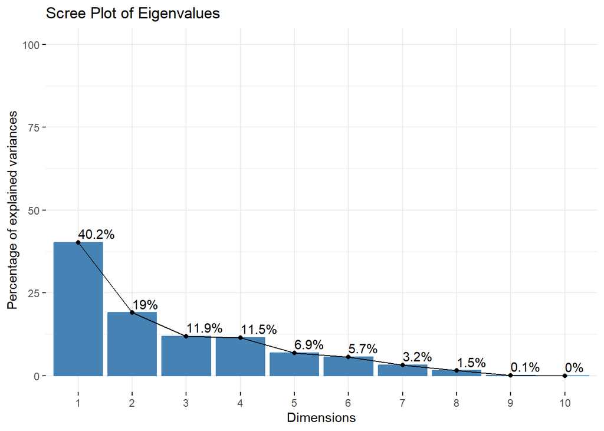

```r
#library(factoextra)

# Scree plot
fviz_eig(fokomp_output, addlabels = TRUE, ylim = c(0, 100), main = "Scree Plot of Eigenvalues")
```

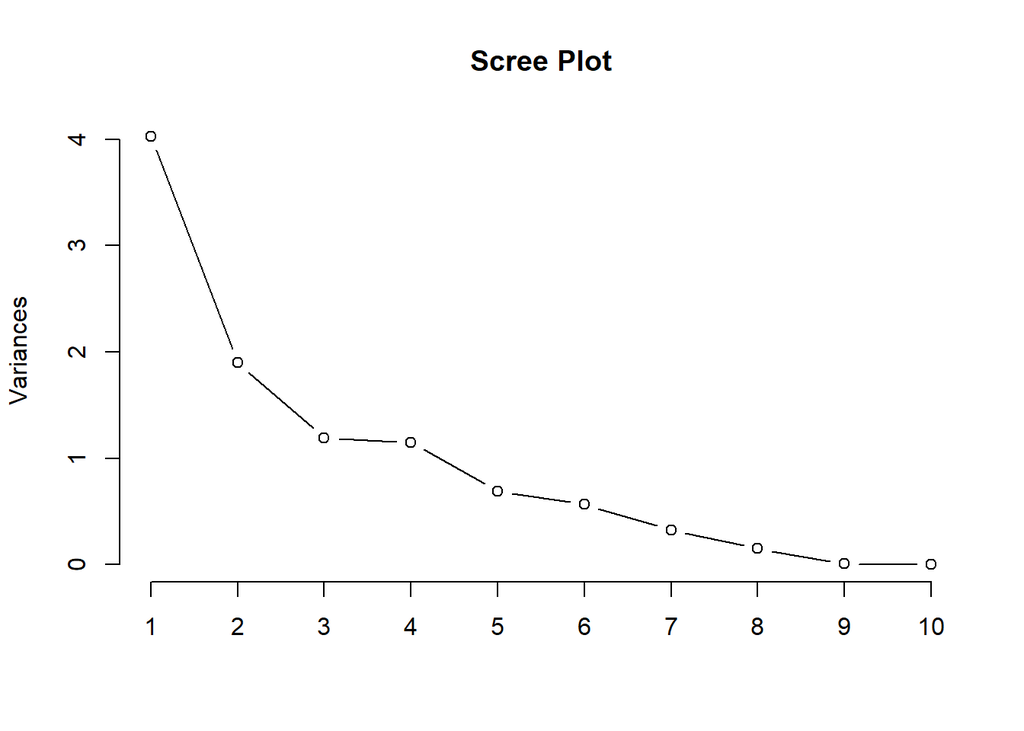

```r
# Basic scree plot with eigenvalues
screeplot(fokomp_output, type = "lines", main = "Scree Plot")
```

Results

```r
elemzes_pca_output <- cbind(elemzes_input_output_cleaned, fokomp_output$x[,1:4])
str(elemzes_pca_output)
```

```
## 'data.frame':    406 obs. of  41 variables:
##  $ ID10     : chr  "611401" "608501" "644001" "623701" ...
##  $ AAA10    : chr  "Rigó József Általános Művelődési Központ és Könyvtár" "Községi Könyvtár Fülöpszállás" "Imre Zoltán Művelődési Központ és Könyvtár" "Városi Könyvtár és Művelődési Ház Kecel" ...
##  $ AIF40    : chr  "köz: községi könyvtár: egyéb intézménnyel összevont" "köz: községi könyvtár" "köz: városi könyvtár: központi: egyéb intézménnyel összevont" "köz: városi könyvtár: központi: egyéb intézménnyel összevont" ...
##  $ AAC10    : chr  "Bugac" "Fülöpszállás" "Jánoshalma" "Kecel" ...
##  $ TAB00    : chr  "nagyközség" "község" "város" "város" ...
##  $ HNT      : num  2592 2241 7984 7932 28803 ...
##  $ TAC00    : chr  "Bács-Kiskun" "Bács-Kiskun" "Bács-Kiskun" "Bács-Kiskun" ...
##  $ HNT_J    : chr  "Kiskunfélegyházi" "Kiskőrösi" "Jánoshalmai" "Kiskőrösi" ...
##  $ osszevont: num  0 0 0 0 0 0 0 0 0 0 ...
##  $ IP1      : num  0.0765 0.493 -1.6917 0.7229 0.0979 ...
##  $ IP2      : num  0.8174 -0.0505 1.6013 -0.8455 -0.0873 ...
##  $ IP3      : num  0.91108 0.52963 -0.37985 0.00196 0.0285 ...
##  $ IL1      : num  0.222 1.717 0.746 0.76 0.55 ...
##  $ IL2      : num  -1.3213 0.5273 -0.8592 -0.0504 0.0651 ...
```

[output cut: 27 more lines]

Correlation heatmap

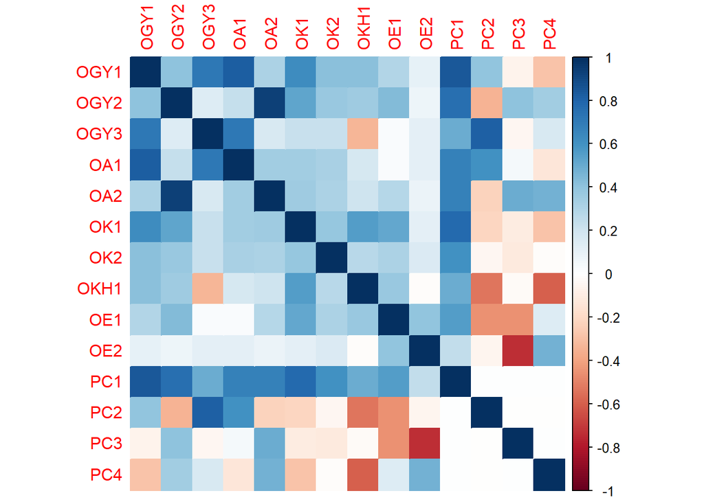

```r
#install.packages("dplyr")
#library(dplyr)

Korr_output <- cor(elemzes_pca_output %>%
                   dplyr::select(27:ncol(elemzes_pca_output)) %>%
                   dplyr::select(-AIF50))

library(corrplot)

corrplot(Korr_output, method="color")
```

## 2.3 Varimax rotation

```r
# # Perform principal component analysis
fokomp_output_varimax <- prcomp(elemzes_input_output_cleaned[,27:36], center = TRUE, scale = TRUE)

# Apply varimax rotation to the first four principal components
varimax_rotation_varimax <- varimax(fokomp_output_varimax$rotation[,1:4])

# Create a new dataset
varimax_output_df_varimax <- scale(elemzes_input_output_cleaned[,27:36]) %*% varimax_rotation_varimax$loadings
```

Results

```r
summary(fokomp_output_varimax)
```

```
## Importance of components:
##                           PC1    PC2    PC3    PC4     PC5     PC6     PC7
## Standard deviation     2.0055 1.3781 1.0918 1.0721 0.83109 0.75261 0.56910
## Proportion of Variance 0.4022 0.1899 0.1192 0.1149 0.06907 0.05664 0.03239
## Cumulative Proportion  0.4022 0.5921 0.7113 0.8263 0.89535 0.95199 0.98438
##                            PC8     PC9      PC10
## Standard deviation     0.38813 0.07446 2.188e-05
## Proportion of Variance 0.01506 0.00055 0.000e+00
## Cumulative Proportion  0.99945 1.00000 1.000e+00
```

Extract summary statistics into a table

```r
summary_prcomp <- summary(fokomp_output_varimax)

standard_deviation <- fokomp_output_varimax$sdev
proportion_of_variance <- summary_prcomp$importance[2, ]
cumulative_proportion <- summary_prcomp$importance[3, ]

prcomp_summary_df <- data.frame(
  Component = seq_along(standard_deviation),
  Standard_Deviation = standard_deviation,
  Proportion_of_Variance = proportion_of_variance,
  Cumulative_Proportion = cumulative_proportion
)

write.csv(prcomp_summary_df, "prcomp_summary.csv", row.names = FALSE)
```

```r
# Append the principal component scores to the original dataset
elemzes_pca_output_varimax <- cbind(elemzes_input_output_cleaned, varimax_output_df_varimax)
```

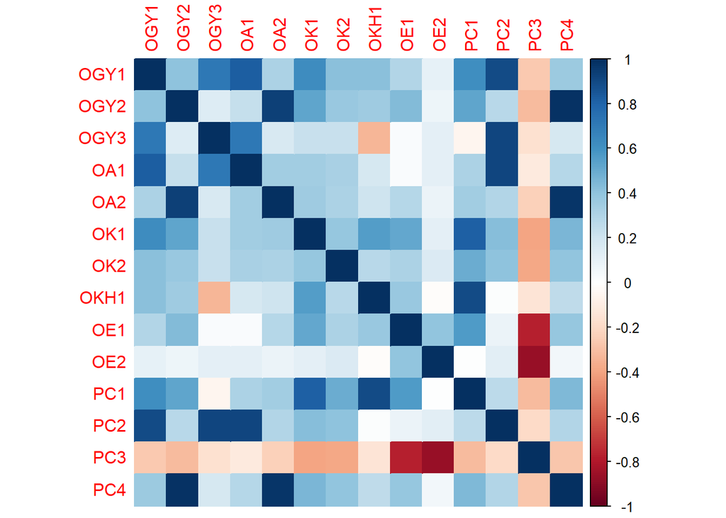

```r
# Calculate the correlation matrix (excluding AIF50)
Korr_output_varimax <- cor(elemzes_pca_output_varimax %>%
                           dplyr::select(27:ncol(elemzes_pca_output_varimax)) %>%
                           dplyr::select(-AIF50))

# Visualise the correlation matrix after varimax rotation
library(corrplot)
corrplot(Korr_output_varimax, method = "color")
```

```r
print(Korr_output_varimax)
```

```
##            OGY1        OGY2        OGY3         OA1         OA2        OK1
## OGY1  1.0000000  0.40847834  0.71522946  0.82403005  0.31098228  0.6246423
## OGY2  0.4084783  1.00000000  0.14986930  0.23987823  0.93575518  0.5228066
## OGY3  0.7152295  0.14986930  1.00000000  0.71764839  0.16097092  0.2208842
## OA1   0.8240300  0.23987823  0.71764839  1.00000000  0.34098994  0.3416301
## OA2   0.3109823  0.93575518  0.16097092  0.34098994  1.00000000  0.3591978
## OK1   0.6246423  0.52280659  0.22088419  0.34163006  0.35919778  1.0000000
## OK2   0.4189960  0.37139170  0.22242938  0.32214388  0.31609836  0.3896390
## OKH1  0.4152038  0.35480933 -0.33883382  0.17517135  0.20911372  0.5533708
## OE1   0.2968621  0.43923588  0.02177658  0.02722868  0.28732988  0.5182959
## OE2   0.1029023  0.07578872  0.11623758  0.11099404  0.08697124  0.1122986
## PC1   0.6147690  0.52245206 -0.05547143  0.31542412  0.34484445  0.8185545
## PC2   0.8949754  0.27452230  0.91199713  0.91299322  0.29001804  0.4225064
## PC3  -0.2642120 -0.31562694 -0.16276800 -0.11391700 -0.23594678 -0.3976081
## PC4   0.3616493  0.98083908  0.17502260  0.28895125  0.97886355  0.4577624
##             OK2        OKH1         OE1          OE2          PC1         PC2
## OGY1  0.4189960  0.41520381  0.29686211  0.102902305  0.614768959  0.89497544
## OGY2  0.3713917  0.35480933  0.43923588  0.075788716  0.522452063  0.27452230
## OGY3  0.2224294 -0.33883382  0.02177658  0.116237582 -0.055471428  0.91199713
## OA1   0.3221439  0.17517135  0.02722868  0.110994037  0.315424119  0.91299322
## OA2   0.3160984  0.20911372  0.28732988  0.086971238  0.344844451  0.29001804
## OK1   0.3896390  0.55337075  0.51829586  0.112298561  0.818554520  0.42250639
## OK2   1.0000000  0.27451898  0.31904806  0.151264578  0.490672694  0.40227082
## OKH1  0.2745190  1.00000000  0.37128762 -0.012776755  0.899806764  0.01769391
## OE1   0.3190481  0.37128762  1.00000000  0.393894243  0.569740836  0.08224043
## OE2   0.1512646 -0.01277676  0.39389424  1.000000000  0.006521245  0.12638939
## PC1   0.4906727  0.89980676  0.56974084  0.006521245  1.000000000  0.26850563
## PC2   0.4022708  0.01769391  0.08224043  0.126389387  0.268505628  1.00000000
## PC3  -0.3898760 -0.14380870 -0.77520170 -0.865419680 -0.312617553 -0.19534965
## PC4   0.3988321  0.25902852  0.38477787  0.051073606  0.440140116  0.29592707
##             PC3         PC4
## OGY1 -0.2642120  0.36164932
## OGY2 -0.3156269  0.98083908
## OGY3 -0.1627680  0.17502260
## OA1  -0.1139170  0.28895125
## OA2  -0.2359468  0.97886355
## OK1  -0.3976081  0.45776238
## OK2  -0.3898760  0.39883213
## OKH1 -0.1438087  0.25902852
## OE1  -0.7752017  0.38477787
## OE2  -0.8654197  0.05107361
## PC1  -0.3126176  0.44014012
## PC2  -0.1953497  0.29592707
## PC3   1.0000000 -0.27780606
## PC4  -0.2778061  1.00000000
```

## 2.4 Principal component analysis without OK2 using varimax rotation

```r
# Perform principal component analysis without OK2
fokomp_output_varimax_OK2 <- prcomp(elemzes_input_output_cleaned[,c(27:32, 34:36)], center = TRUE, scale = TRUE)

# Apply varimax rotation to the first four principal components
varimax_rotation_varimax_OK2 <- varimax(fokomp_output_varimax_OK2$rotation[,1:4])

# Create a new dataset
varimax_output_df_varimax_OK2 <- scale(elemzes_input_output_cleaned[,c(27:32, 34:36)]) %*% varimax_rotation_varimax_OK2$loadings
```

```r
# Append the principal component scores to the original dataset
elemzes_pca_output_varimax_OK2 <- cbind(elemzes_input_output_cleaned, varimax_output_df_varimax_OK2)
```

Results

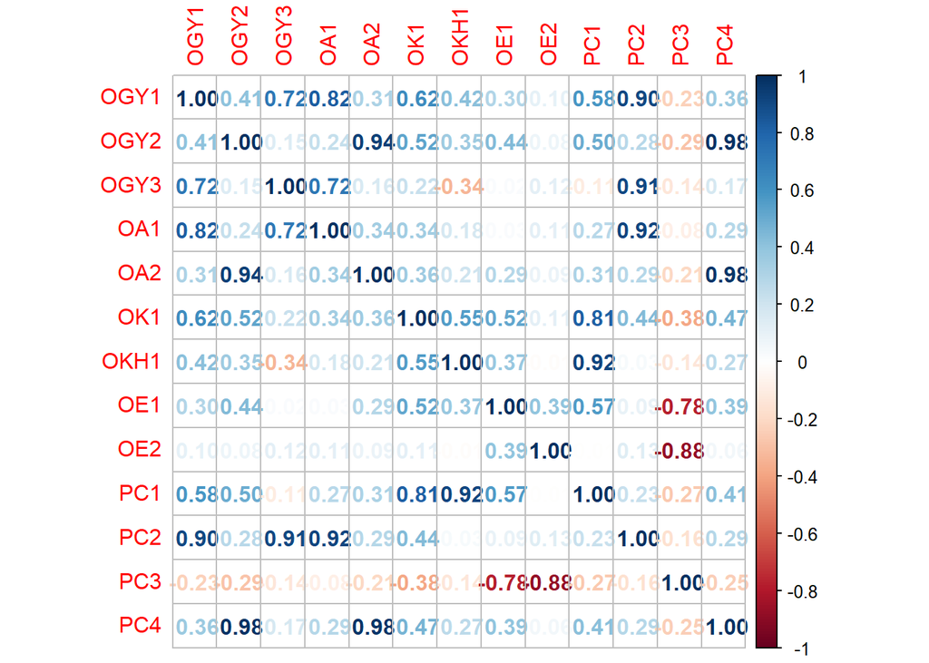

```r
Korr_output_varimax_OK2 <- cor(
  elemzes_pca_output_varimax_OK2[, c(27:32, 34:36, 38:41)],
  use = "complete.obs"
)

# Visualise the correlation matrix after varimax rotation
library(corrplot)
corrplot(Korr_output_varimax_OK2, method = "number")
```

Export

```r
# PNG mentése 300 DPI-ben
png("Korr_output_varimax_OK2.png",
    width = 22,
    height = 20,
    units = "cm",
    res = 300)

png("Korr_output_varimax_OK2.tiff",
    width = 22,
    height = 20,
    units = "cm",
    res = 300)

library(corrplot)
corrplot(Korr_output_varimax_OK2,
         method = "number",
         number.cex = 0.7,
         tl.cex = 0.8,
         tl.col = "black",
         mar = c(0, 0, 1, 0))

dev.off()
```

Summary

```r
summary(fokomp_output_varimax_OK2)
```

```
## Importance of components:
##                           PC1    PC2    PC3    PC4     PC5     PC6     PC7
## Standard deviation     1.9287 1.3774 1.0892 1.0720 0.75263 0.56952 0.38816
## Proportion of Variance 0.4133 0.2108 0.1318 0.1277 0.06294 0.03604 0.01674
## Cumulative Proportion  0.4133 0.6241 0.7560 0.8837 0.94660 0.98264 0.99938
##                            PC8       PC9
## Standard deviation     0.07463 2.191e-05
## Proportion of Variance 0.00062 0.000e+00
## Cumulative Proportion  1.00000 1.000e+00
```

Examine the principal components using histograms

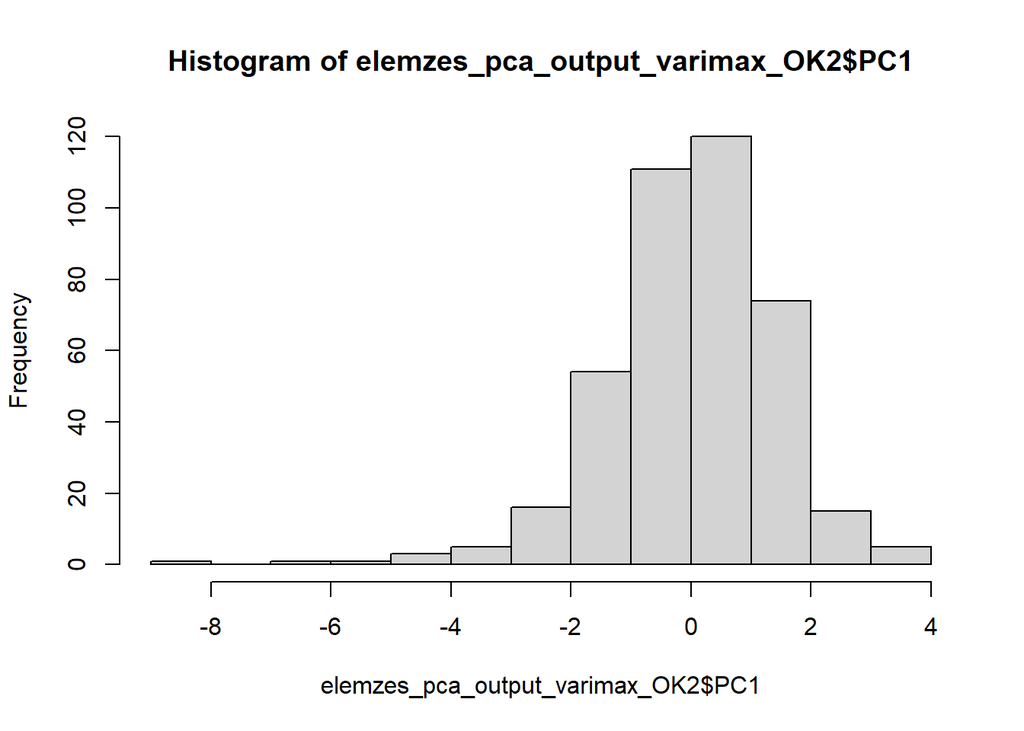

```r
hist(elemzes_pca_output_varimax_OK2$PC1)
```

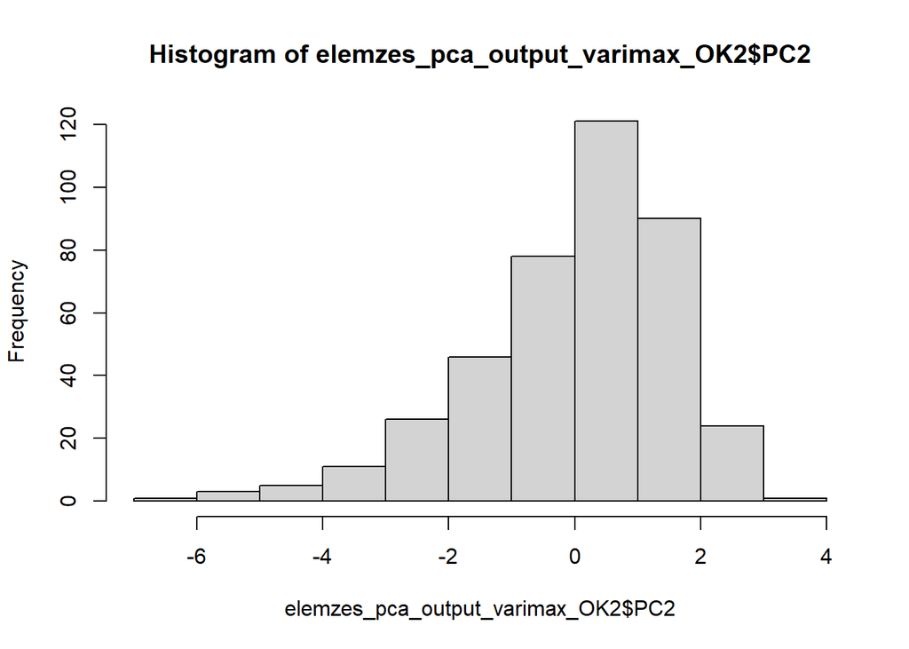

```r
hist(elemzes_pca_output_varimax_OK2$PC2)
```

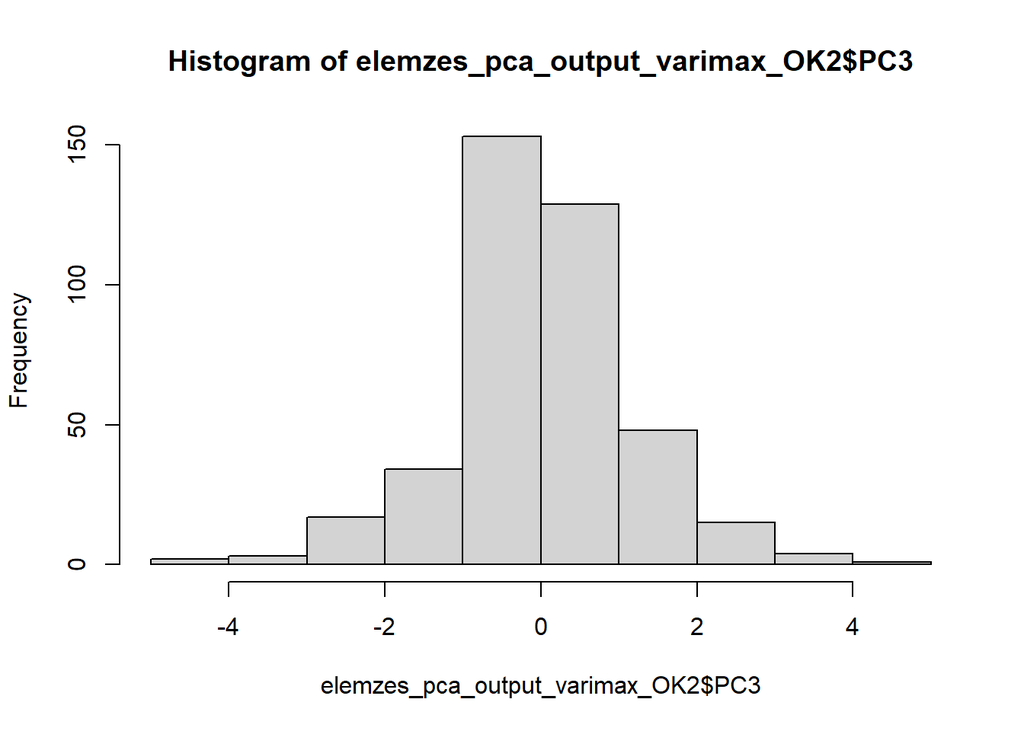

```r
hist(elemzes_pca_output_varimax_OK2$PC3)
```

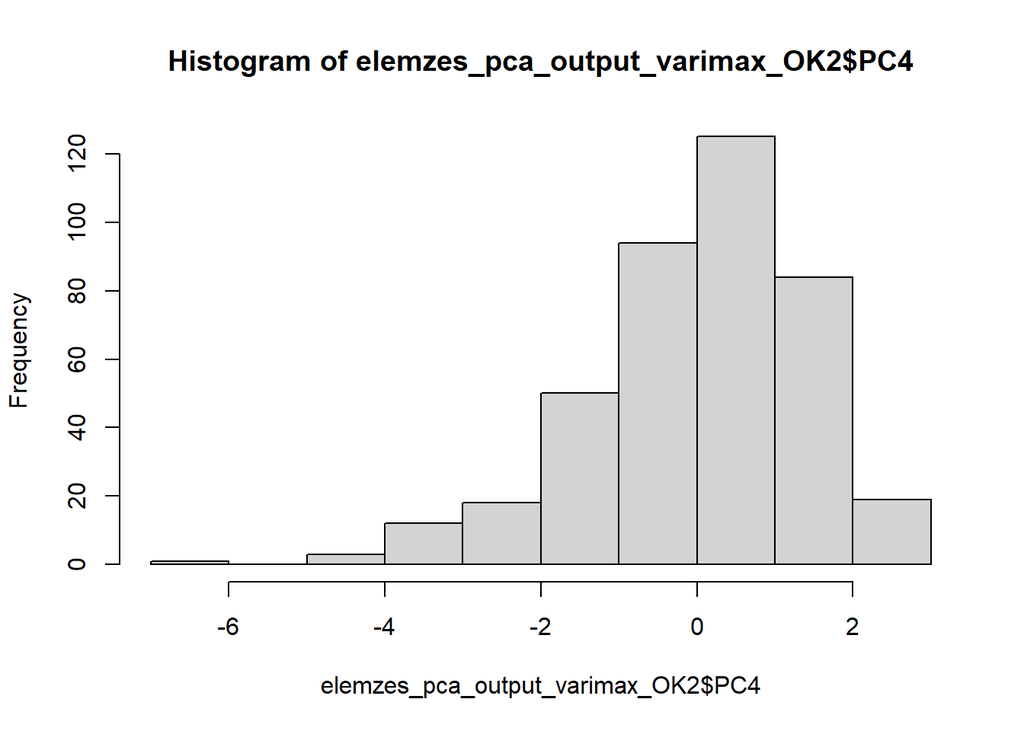

```r
hist(elemzes_pca_output_varimax_OK2$PC4)
```

# LIBRARY DEMAND INDEX AND RANKING

## 2.5 Preparations

```r
# Reverse the sign of PC3
elemzes_pca_output_varimax_OK2 <- elemzes_pca_output_varimax_OK2 %>%
  mutate(PC3 = PC3 * -1)
```

Create histogram

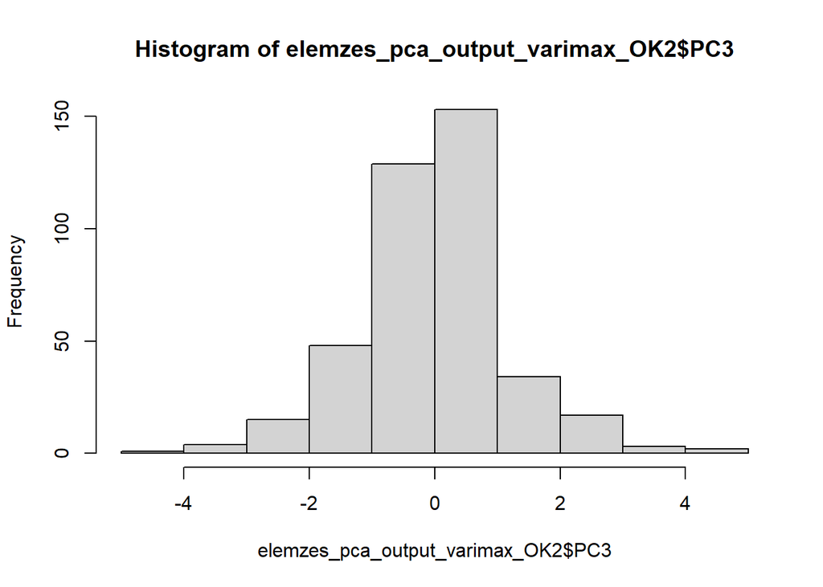

```r
hist(elemzes_pca_output_varimax_OK2$PC3)
```

## Construct the Library Demand Index and ranking

```r
# 1. Standardisation
# Standardise OK2 and all principal components (PC1, PC2, PC3 and PC4)
elemzes_pca_output_varimax_index <- elemzes_pca_output_varimax_OK2 %>%
  mutate(
    PC1_std = scale(PC1),
    PC2_std = scale(PC2),
    PC3_std = scale(PC3),
    PC4_std = scale(PC4),
    OK2_std = scale(OK2)
  )

# 2. Unweighted mean
# Calculate the unweighted mean of all standardised components
elemzes_pca_output_varimax_index <- elemzes_pca_output_varimax_index %>%
  mutate(KKI = (PC1_std + PC2_std + PC3_std + PC4_std + OK2_std)/5)

# 3. Ranking
# Rank libraries based on the Library Demand Index
elemzes_pca_output_varimax_index <- elemzes_pca_output_varimax_index %>%
  arrange(desc(KKI)) %>%
  mutate(KKI_rank = min_rank(desc(KKI)))

# Apply min–max scaling to the Library Demand Index (0–100)
elemzes_pca_output_varimax_index <- elemzes_pca_output_varimax_index %>%
  mutate(KKI_100 = (KKI - min(KKI)) / (max(KKI) - min(KKI)) * 100)

# Export the results
write_xlsx(elemzes_pca_output_varimax_index, "elemzes_pca_output_varimax_index.xlsx")
```

## 2.6 Example analysis

1. Scatter plots illustrating the relationships between principal components

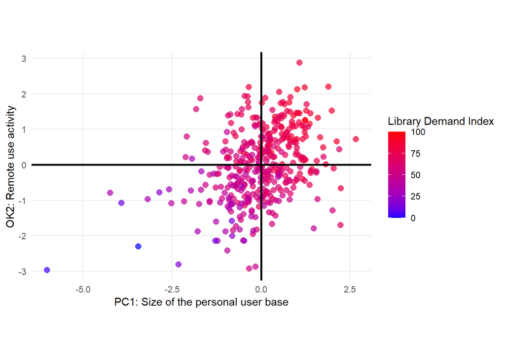

```r
KKI100_PC1_OK2 <- ggplot(elemzes_pca_output_varimax_index, aes(x = PC1_std, y = OK2_std)) +
  geom_point(aes(color = KKI_100), size = 2.5, alpha = 0.7) +
  scale_color_gradient(low = "blue", high = "red") +

  geom_hline(yintercept = 0, linewidth = 1) +
  geom_vline(xintercept = 0, linewidth = 1) +

  coord_fixed() +

  labs(
    x = "PC1: Size of the personal user base",
    y = "OK2: Remote use activity",
    color = "Library Demand Index"
  ) +
  theme_minimal() +
  theme(panel.grid.minor = element_blank())

print(KKI100_PC1_OK2)
```

```r
ggsave("KKI100_PC1_OK2_matrix.png",
       plot = KKI100_PC1_OK2,
       width = 10,
       height = 8,
       units = "in",
       dpi = 300,
       bg = "white")

ggsave("KKI100_PC1_OK2_matrix.tiff",
       plot = KKI100_PC1_OK2,
       width = 10,
       height = 8,
       units = "in",
       dpi = 300,
       bg = "white")
```

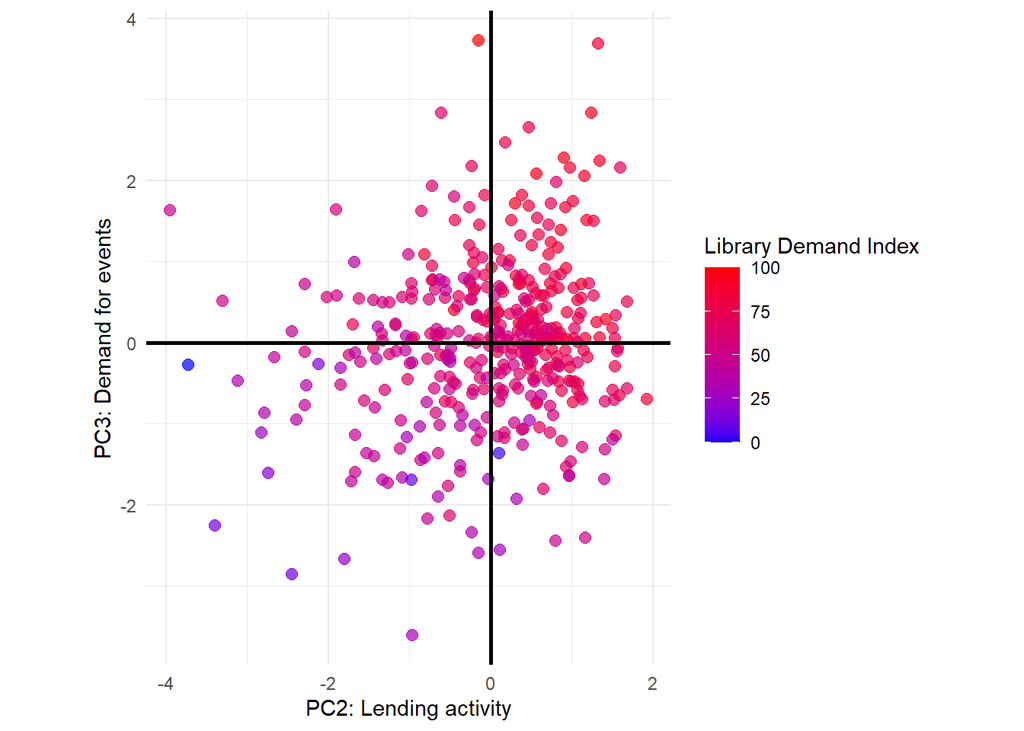

```r
KKI100_PC2_PC3 <- ggplot(elemzes_pca_output_varimax_index, aes(x = PC2_std, y = PC3_std)) +
  geom_point(aes(color = KKI_100), size = 2.5, alpha = 0.7) +
  scale_color_gradient(low = "blue", high = "red") +

  # 4 részre bontás
  geom_hline(yintercept = 0, linewidth = 1) +
  geom_vline(xintercept = 0, linewidth = 1) +

  coord_fixed() +

  labs(
    x = "PC2: Lending activity",
    y = "PC3: Demand for events",
    color = "Library Demand Index"
  ) +
  theme_minimal()

print(KKI100_PC2_PC3)
```

```r
ggsave("KKI100_PC2_PC3_matrix.png",
       plot = KKI100_PC2_PC3,
       width = 10,
       height = 8,
       units = "in",
       dpi = 300,
       bg = "white")

ggsave("KKI100_PC2_PC3_matrix.tiff",
       plot = KKI100_PC2_PC3,
       width = 10,
       height = 8,
       units = "in",
       dpi = 300,
       bg = "white")
```

# 3 MULTIPLE LINEAR REGRESSION

## 3.1 Review correlations

Correlation matrix of the input variables and the Library Demand Index (KKI_100)

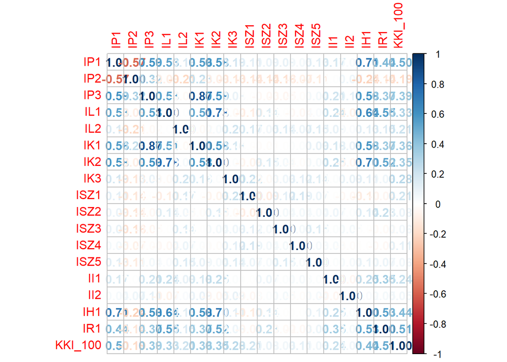

```r
Korr_input_output <- cor(elemzes_pca_output_varimax_index[,c(10:26, 49)], use = "complete.obs")

library(corrplot)
corrplot(Korr_input_output, method = "number")
```

```r
print(Korr_input_output)
```

```
##                 IP1          IP2          IP3          IL1          IL2
## IP1      1.00000000 -0.574782737  0.590611621  0.531890517  0.157716819
## IP2     -0.57478274  1.000000000  0.320863575 -0.085406395 -0.209483469
## IP3      0.59061162  0.320863575  1.000000000  0.531394369 -0.024041189
## IL1      0.53189052 -0.085406395  0.531394369  1.000000000  0.001313291
## IL2      0.15771682 -0.209483469 -0.024041189  0.001313291  1.000000000
## IK1      0.55688561  0.233269246  0.874588955  0.513869510 -0.024820341
## IK2      0.58376381 -0.081852581  0.594938634  0.779398248  0.035485197
## IK3      0.18654690 -0.133926972  0.083847486 -0.023110733  0.195228973
## ISZ1     0.11458398 -0.137654504 -0.003120085 -0.097904973  0.168278104
## ISZ2     0.08820279 -0.137186630 -0.033188755  0.139269641  0.050993729
## ISZ3     0.09160097 -0.157880152 -0.049677434 -0.009486144  0.144518702
## ISZ4     0.04705082 -0.070001889 -0.014569206 -0.039671220  0.070089143
## ISZ5     0.12959052 -0.109799437  0.041717775  0.025826664  0.149304408
## II1      0.17372345  0.008833221  0.209784955  0.239779388  0.094580277
## II2      0.03737733  0.065591867  0.107947658 -0.067294196  0.025674482
## IH1      0.70577213 -0.236396800  0.583761201  0.644665004  0.127474985
## IR1      0.44130839 -0.139575191  0.373148936  0.545362382  0.152424053
## KKI_100  0.49676487 -0.191181713  0.386439680  0.326861948  0.211431895
##                  IK1         IK2         IK3         ISZ1        ISZ2
## IP1      0.556885606  0.58376381  0.18654690  0.114583981  0.08820279
## IP2      0.233269246 -0.08185258 -0.13392697 -0.137654504 -0.13718663
## IP3      0.874588955  0.59493863  0.08384749 -0.003120085 -0.03318875
## IL1      0.513869510  0.77939825 -0.02311073 -0.097904973  0.13926964
## IL2     -0.024820341  0.03548520  0.19522897  0.168278104  0.05099373
## IK1      1.000000000  0.57908562  0.16088979 -0.005903417 -0.01175416
## IK2      0.579085616  1.00000000  0.01608762 -0.056637326  0.14696291
## IK3      0.160889793  0.01608762  1.00000000  0.219140895 -0.02515912
## ISZ1    -0.005903417 -0.05663733  0.21914090  1.000000000 -0.09224283
## ISZ2    -0.011754157  0.14696291 -0.02515912 -0.092242833  1.00000000
## ISZ3    -0.009865012  0.04346243  0.06354089  0.116113654  0.04360376
## ISZ4     0.011457439 -0.01155905  0.11670389  0.187457424  0.04198831
## ISZ5     0.091758695  0.04467080  0.13624877  0.072939400  0.03671565
## II1      0.177641159  0.24595987  0.01398143 -0.002263977  0.06509219
## II2      0.087844804 -0.04956621  0.09363466 -0.032397054  0.01363870
## IH1      0.582288317  0.69545673  0.11040425 -0.101263757  0.14328279
## IR1      0.368436736  0.51869741  0.06396530 -0.040153996  0.23457112
## KKI_100  0.357755950  0.35405839  0.27750651  0.205856946  0.08173468
##                 ISZ3          ISZ4        ISZ5          II1         II2
## IP1      0.091600970  0.0470508217  0.12959052  0.173723445  0.03737733
```

[output cut: 21 more lines]

```
## IL1      0.6446650043  0.54536238  0.32686195
## IL2      0.1274749851  0.15242405  0.21143189
## IK1      0.5822883173  0.36843674  0.35775595
## IK2      0.6954567299  0.51869741  0.35405839
## IK3      0.1104042540  0.06396530  0.27750651
## ISZ1    -0.1012637566 -0.04015400  0.20585695
## ISZ2     0.1432827944  0.23457112  0.08173468
## ISZ3    -0.0065209976 -0.02301211  0.05930793
## ISZ4    -0.0007320261 -0.03127639  0.10571232
## ISZ5     0.0970376480  0.07468630  0.05613413
## II1      0.2535096685  0.34586232  0.23782787
## II2      0.0216497273  0.04528729  0.05283895
## IH1      1.0000000000  0.53021781  0.44411870
## IR1      0.5302178116  1.00000000  0.50717820
## KKI_100  0.4441186994  0.50717820  1.00000000
```

## 3.2 Perform multiple linear regression

Introduce the `TelepulesIndex` variable into the analysis.

```r
# Import the settlement development index dataset
telepulesindex <- read_excel("telepulesindex.xlsx")

# Merge the datasets using the AAC10 variable
elemzes_pca_output_varimax_index_ti <- elemzes_pca_output_varimax_index %>%
  left_join(telepulesindex, by = "AAC10")

# Export the merged dataset to an Excel file
write_xlsx(elemzes_pca_output_varimax_index_ti, "elemzes_pca_output_varimax_index_ti.xlsx")

# Inspect the merged dataset
head(elemzes_pca_output_varimax_index_ti)
```

|  | ID10 | AAA10 | AIF40 | AAC10 | TAB00 | HNT | TAC00 | HNT_J | osszevont | IP1 | IP2 | IP3 | IL1 | IL2 | IK1 | IK2 | IK3 | ISZ1 | ISZ2 | ISZ3 | ISZ4 | ISZ5 | II1 | II2 | IH1 | IR1 | OGY1 | OGY2 | OGY3 | … |
| --- | --- | --- | --- | --- | --- | --- | --- | --- | --- | --- | --- | --- | --- | --- | --- | --- | --- | --- | --- | --- | --- | --- | --- | --- | --- | --- | --- | --- | --- | --- |
| 1 | 500001500017500003500018500802500019 | Verseghy Ferenc Könyvtár és Közművelődési Intézmény, Verseghy Ferenc Könyvtár és Közművelődési Intézmény Pletykafalu Fiókkönyvtára és Közösségi Tere, Verseghy Ferenc Könyvtár és Közművelődési Intézmén… | köz: összesített | Szolnok | megyeszékhely, megyei jogú város | 67126 | Jász-Nagykun-Szolnok | Szolnoki | 2 | 1.3660992 | -1.72009406 | -0.1198861 | 0.452033528 | 0.64278843 | 0.2327902 | 1.03218065 | 1.4651041 | 1 | 1 | 0 | 1 | 0 | 0.3883949 | 0 | 1.3301863 | 1.1312612 | 0.4666302 | 1.496993 | -0.34820431 | … |
| 2 | 650001 | Ady Endre Városi Könyvtár | köz: városi könyvtár: központi | Baja | város | 33142 | Bács-Kiskun | Bajai | 0 | 0.2733203 | -0.07488069 | 0.2470438 | 0.008890363 | 0.52725275 | 0.1038344 | 0.08972234 | 1.5710040 | 1 | 1 | 0 | 0 | 0 | 0.1786947 | 0 | 0.2349434 | 0.3790089 | 0.8376743 | 1.781099 | 0.49621589 | … |
| 3 | 620001 | Petőfi Sándor Városi Könyvtár | köz: városi könyvtár: központi | Kiskőrös | város | 13320 | Bács-Kiskun | Kiskőrösi | 0 | 0.4328712 | 0.37715581 | 0.8881010 | 0.724376550 | 0.06511004 | 0.7060310 | 0.87922459 | 0.9948726 | 1 | 1 | 0 | 1 | 0 | 0.4078011 | 0 | 0.5958352 | 0.4223475 | 0.7335784 | 1.245679 | 0.06092774 | … |
| 4 | 896001896005896003 | Városi Könyvtár Lenti, Városi Könyvtár Lenti Máhomfai úti Fiókkönyvtára, Városi Könyvtár Lenti Mihályfai úti Fiókkönyvtára | köz: összesített | Lenti | város | 7056 | Zala | Lenti | 2 | 1.4120483 | -0.45778013 | 1.2007753 | 1.022922606 | 0.41171707 | 1.1769007 | 1.15552530 | -0.5972955 | 1 | 0 | 0 | 1 | 0 | 0.7953599 | 0 | 2.0624037 | 1.1352179 | 0.9741843 | 1.203191 | 0.50848847 | … |
| 5 | 970001970019970021 | Berzsenyi Dániel Könyvtár, Berzsenyi Dániel Könyvtár Hunyadi úti Fiókkönyvtára, Berzsenyi Dániel Könyvtár Kámoni Fiókkönyvtára | köz: összesített | Szombathely | megyeszékhely, megyei jogú város | 78446 | Vas | Szombathelyi | 2 | 1.1514173 | -0.70559309 | 0.6458789 | -0.115210741 | 0.52725275 | 0.5938636 | 0.39565222 | 0.4399105 | 1 | 1 | 0 | 1 | 0 | -0.1365160 | 1 | 0.3252904 | 0.8108072 | 1.5486080 | 1.804976 | 1.02012485 | … |
| 6 | 990001 | Faludi Ferenc Könyvtár | köz: városi könyvtár: központi | Körmend | város | 10255 | Vas | Körmendi | 0 | 1.2469787 | -0.30902852 | 1.1560909 | 1.593277728 | 0.75832411 | 1.0999946 | 1.45985939 | 1.5100583 | 1 | 1 | 0 | 1 | 0 | 0.5500523 | 0 | 1.4438183 | 0.8880382 | 1.6162625 | 1.818164 | 0.81290827 | … |

Visualizing the relationship between settlement index (TelepulesIndex) and Library Demand Index

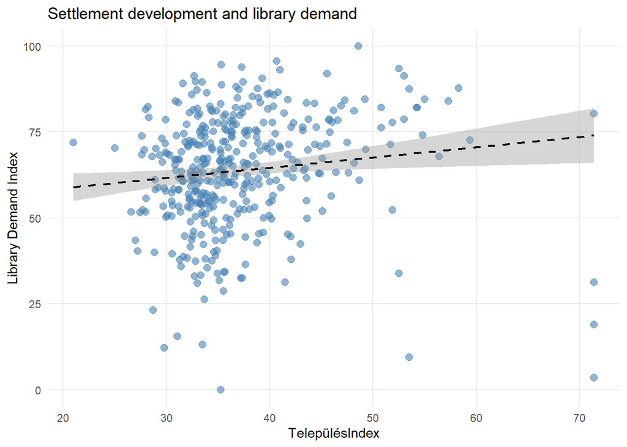

```r
library(ggplot2)

KKI100TI <- ggplot(elemzes_pca_output_varimax_index_ti, aes(x = TelepulesIndex, y = KKI_100)) +
  geom_point(color = "steelblue", size = 2.5, alpha = 0.6) +


  geom_smooth(method = "lm", color = "black", linetype = "dashed", se = TRUE, linewidth = 0.8) +

  labs(
    title = "Settlement development and library demand",
    x = "TelepülésIndex",
    y = "Library Demand Index"
  ) +
  theme_minimal() +
  theme(panel.grid.minor = element_blank())

print(KKI100TI)
```

Calculate the correlation matrix for the variables included in the multiple regression analysis

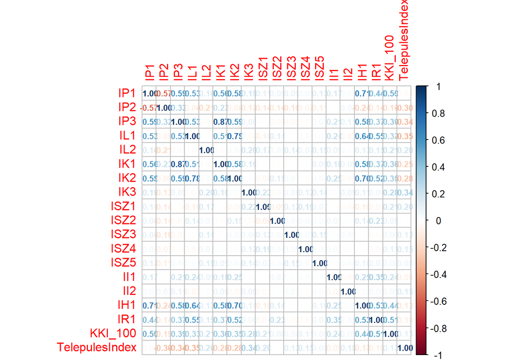

```r
# Calculate the correlation matrix (columns 10–26, 49 and 50)
Korr_input_output_2 <- cor(elemzes_pca_output_varimax_index_ti[, c(10:26, 49, 50)], use = "complete.obs")

library(corrplot)
corrplot(Korr_input_output_2, method = "number", number.cex = 0.7)
```

```r
print(Korr_input_output_2)
```

```
##                        IP1          IP2          IP3          IL1          IL2
## IP1             1.00000000 -0.574782737  0.590611621  0.531890517  0.157716819
## IP2            -0.57478274  1.000000000  0.320863575 -0.085406395 -0.209483469
## IP3             0.59061162  0.320863575  1.000000000  0.531394369 -0.024041189
## IL1             0.53189052 -0.085406395  0.531394369  1.000000000  0.001313291
## IL2             0.15771682 -0.209483469 -0.024041189  0.001313291  1.000000000
## IK1             0.55688561  0.233269246  0.874588955  0.513869510 -0.024820341
## IK2             0.58376381 -0.081852581  0.594938634  0.779398248  0.035485197
## IK3             0.18654690 -0.133926972  0.083847486 -0.023110733  0.195228973
## ISZ1            0.11458398 -0.137654504 -0.003120085 -0.097904973  0.168278104
## ISZ2            0.08820279 -0.137186630 -0.033188755  0.139269641  0.050993729
## ISZ3            0.09160097 -0.157880152 -0.049677434 -0.009486144  0.144518702
## ISZ4            0.04705082 -0.070001889 -0.014569206 -0.039671220  0.070089143
## ISZ5            0.12959052 -0.109799437  0.041717775  0.025826664  0.149304408
## II1             0.17372345  0.008833221  0.209784955  0.239779388  0.094580277
## II2             0.03737733  0.065591867  0.107947658 -0.067294196  0.025674482
## IH1             0.70577213 -0.236396800  0.583761201  0.644665004  0.127474985
## IR1             0.44130839 -0.139575191  0.373148936  0.545362382  0.152424053
## KKI_100         0.49676487 -0.191181713  0.386439680  0.326861948  0.211431895
## TelepulesIndex -0.03927258 -0.298242741 -0.339544941 -0.352474089  0.202991185
##                         IK1         IK2         IK3         ISZ1         ISZ2
## IP1             0.556885606  0.58376381  0.18654690  0.114583981  0.088202786
## IP2             0.233269246 -0.08185258 -0.13392697 -0.137654504 -0.137186630
## IP3             0.874588955  0.59493863  0.08384749 -0.003120085 -0.033188755
## IL1             0.513869510  0.77939825 -0.02311073 -0.097904973  0.139269641
## IL2            -0.024820341  0.03548520  0.19522897  0.168278104  0.050993729
## IK1             1.000000000  0.57908562  0.16088979 -0.005903417 -0.011754157
## IK2             0.579085616  1.00000000  0.01608762 -0.056637326  0.146962911
## IK3             0.160889793  0.01608762  1.00000000  0.219140895 -0.025159122
## ISZ1           -0.005903417 -0.05663733  0.21914090  1.000000000 -0.092242833
## ISZ2           -0.011754157  0.14696291 -0.02515912 -0.092242833  1.000000000
## ISZ3           -0.009865012  0.04346243  0.06354089  0.116113654  0.043603764
## ISZ4            0.011457439 -0.01155905  0.11670389  0.187457424  0.041988309
## ISZ5            0.091758695  0.04467080  0.13624877  0.072939400  0.036715654
## II1             0.177641159  0.24595987  0.01398143 -0.002263977  0.065092190
## II2             0.087844804 -0.04956621  0.09363466 -0.032397054  0.013638700
## IH1             0.582288317  0.69545673  0.11040425 -0.101263757  0.143282794
## IR1             0.368436736  0.51869741  0.06396530 -0.040153996  0.234571115
## KKI_100         0.357755950  0.35405839  0.27750651  0.205856946  0.081734684
## TelepulesIndex -0.249474525 -0.28167116  0.34190268  0.202886470  0.002943258
```

[output cut: 25 more lines]

```
## IL2             0.1274749851  0.15242405  0.21143189    0.202991185
## IK1             0.5822883173  0.36843674  0.35775595   -0.249474525
## IK2             0.6954567299  0.51869741  0.35405839   -0.281671159
## IK3             0.1104042540  0.06396530  0.27750651    0.341902682
## ISZ1           -0.1012637566 -0.04015400  0.20585695    0.202886470
## ISZ2            0.1432827944  0.23457112  0.08173468    0.002943258
## ISZ3           -0.0065209976 -0.02301211  0.05930793    0.129223893
## ISZ4           -0.0007320261 -0.03127639  0.10571232    0.152617737
## ISZ5            0.0970376480  0.07468630  0.05613413    0.076198357
## II1             0.2535096685  0.34586232  0.23782787   -0.087335473
## II2             0.0216497273  0.04528729  0.05283895    0.149712185
## IH1             1.0000000000  0.53021781  0.44411870   -0.131985890
## IR1             0.5302178116  1.00000000  0.50717820   -0.099791676
## KKI_100         0.4441186994  0.50717820  1.00000000    0.127230400
## TelepulesIndex -0.1319858900 -0.09979168  0.12723040    1.000000000
```

### 3.2.1 Fit the initial model

Initial model: KKI_reg

```r
KKI_reg <- lm(KKI_100 ~ IP1 + IP2 + IP3 + IL1 + IL2 + IK1 + IK2 + IK3 + ISZ1 + ISZ2 + ISZ3 + ISZ4 + ISZ5 + II1 + II2 + IH1 + IR1 + log(TelepulesIndex), data = elemzes_pca_output_varimax_index_ti)
summary(KKI_reg)
```

```
##
## Call:
## lm(formula = KKI_100 ~ IP1 + IP2 + IP3 + IL1 + IL2 + IK1 + IK2 +
##     IK3 + ISZ1 + ISZ2 + ISZ3 + ISZ4 + ISZ5 + II1 + II2 + IH1 +
##     IR1 + log(TelepulesIndex), data = elemzes_pca_output_varimax_index_ti)
##
## Residuals:
##     Min      1Q  Median      3Q     Max
## -45.193  -7.101   0.518   7.991  40.209
##
## Coefficients:
##                       Estimate Std. Error t value Pr(>|t|)
## (Intercept)          7.137e+00  1.628e+01   0.438 0.661410
## IP1                  2.614e+03  5.546e+03   0.471 0.637605
## IP2                  2.231e+03  4.736e+03   0.471 0.637947
## IP3                 -2.219e+03  4.721e+03  -0.470 0.638555
## IL1                  3.857e-02  1.079e+00   0.036 0.971505
## IL2                  7.743e-01  6.789e-01   1.141 0.254780
## IK1                 -1.464e+00  1.317e+00  -1.112 0.266962
## IK2                 -7.943e-01  1.127e+00  -0.705 0.481372
## IK3                  1.927e+00  6.933e-01   2.779 0.005722 **
## ISZ1                 4.697e+00  1.458e+00   3.222 0.001382 **
## ISZ2                -1.612e-02  1.314e+00  -0.012 0.990216
## ISZ3                 1.601e+00  2.574e+00   0.622 0.534236
## ISZ4                 1.975e+00  1.657e+00   1.192 0.233843
## ISZ5                -5.052e+00  4.097e+00  -1.233 0.218295
## II1                  7.803e-01  6.716e-01   1.162 0.245992
## II2                 -7.350e-01  1.410e+00  -0.521 0.602581
## IH1                  1.413e+00  1.081e+00   1.307 0.191867
## IR1                  6.095e+00  8.770e-01   6.950 1.56e-11 ***
## log(TelepulesIndex)  1.503e+01  4.490e+00   3.347 0.000896 ***
## ---
## Signif. codes:  0 '***' 0.001 '**' 0.01 '*' 0.05 '.' 0.1 ' ' 1
##
## Residual standard error: 12.35 on 387 degrees of freedom
## Multiple R-squared:  0.4509, Adjusted R-squared:  0.4254
## F-statistic: 17.66 on 18 and 387 DF,  p-value: < 2.2e-16
```

```r
#library(lmtest)

# Perform the Breusch–Pagan test
bptest(KKI_reg, studentize = TRUE)
```

```
##
##  studentized Breusch-Pagan test
##
## data:  KKI_reg
## BP = 35.603, df = 18, p-value = 0.007929
```

Calculate variance inflation factors (VIF)

```r
#library(car)
vif(KKI_reg)
```

```
##                 IP1                 IP2                 IP3                 IL1
##        8.095934e+07        5.876993e+07        6.043534e+07        3.063916e+00
##                 IL2                 IK1                 IK2                 IK3
##        1.179151e+00        4.692062e+00        3.325673e+00        1.281287e+00
##                ISZ1                ISZ2                ISZ3                ISZ4
##        1.216489e+00        1.114991e+00        1.094890e+00        1.065755e+00
##                ISZ5                 II1                 II2                 IH1
##        1.073351e+00        1.172328e+00        1.097236e+00        3.099999e+00
##                 IR1 log(TelepulesIndex)
##        1.777179e+00        1.537411e+00
```

Since both multicollinearity and heteroskedasticity are present, heteroskedasticity is addressed first using coefficient estimation based on the Generalized Least Squares (GLS) approach.

### 3.2.2 GLS

```r
# Original regression model
KKI_reg <- lm(KKI_100 ~ IP1 + IP2 + IP3 + IL1 + IL2 + IK1 + IK2 + IK3 +
                ISZ1 + ISZ2 + ISZ3 + ISZ4 + ISZ5 + II1 + II2 + IH1 + IR1 +
                log(TelepulesIndex), data = elemzes_pca_output_varimax_index_ti)

elemzes_pca_output_varimax_index_ti$HibatagNegyzet <- residuals(KKI_reg)^2

tabla_white_teszt <- elemzes_pca_output_varimax_index_ti[, c("IP1", "IP2", "IP3", "IL1", "IL2",
                                                             "IK1", "IK2", "IK3", "ISZ1", "ISZ2",
                                                             "ISZ3", "ISZ4", "ISZ5", "II1", "II2",
                                                             "IH1", "IR1", "TelepulesIndex")]

tabla_white_teszt$HibatagNegyzet <- elemzes_pca_output_varimax_index_ti$HibatagNegyzet

negyzetek <- tabla_white_teszt[, 1:(ncol(tabla_white_teszt) - 1)]^2
colnames(negyzetek) <- paste0(colnames(tabla_white_teszt)[1:(ncol(tabla_white_teszt) - 1)], "_negyzete")
tabla_white_teszt <- cbind(tabla_white_teszt, negyzetek)

seged_reg_gls <- lm(log(HibatagNegyzet) ~ ., data = tabla_white_teszt)

omega_elemek <- exp(fitted(seged_reg_gls))

# Fit the weighted regression model
KKI_reg_gls <- lm(KKI_100 ~ IP1 + IP2 + IP3 + IL1 + IL2 + IK1 + IK2 + IK3 +
                       ISZ1 + ISZ2 + ISZ3 + ISZ4 + ISZ5 + II1 + II2 + IH1 + IR1 +
                       log(TelepulesIndex), weights = 1/omega_elemek,
                     data = elemzes_pca_output_varimax_index_ti)

summary(KKI_reg_gls)
```

```
##
## Call:
## lm(formula = KKI_100 ~ IP1 + IP2 + IP3 + IL1 + IL2 + IK1 + IK2 +
##     IK3 + ISZ1 + ISZ2 + ISZ3 + ISZ4 + ISZ5 + II1 + II2 + IH1 +
##     IR1 + log(TelepulesIndex), data = elemzes_pca_output_varimax_index_ti,
##     weights = 1/omega_elemek)
##
## Weighted Residuals:
##     Min      1Q  Median      3Q     Max
## -6.5999 -1.1634  0.1134  1.3468  6.1618
##
## Coefficients:
##                      Estimate Std. Error t value Pr(>|t|)
## (Intercept)           -5.3702    12.7913  -0.420  0.67484
## IP1                 -863.8541  4042.7684  -0.214  0.83091
## IP2                 -739.4411  3452.6633  -0.214  0.83053
## IP3                  742.5509  3441.6196   0.216  0.82929
## IL1                    0.7409     0.9725   0.762  0.44663
## IL2                    0.8164     0.6397   1.276  0.20267
## IK1                   -3.4551     1.0465  -3.302  0.00105 **
## IK2                   -0.4817     0.9540  -0.505  0.61389
## IK3                    1.6139     0.5608   2.878  0.00422 **
## ISZ1                   4.0861     1.3554   3.015  0.00274 **
## ISZ2                   0.4014     1.1615   0.346  0.72985
## ISZ3                   0.1509     2.8235   0.053  0.95741
## ISZ4                   0.2328     1.4775   0.158  0.87487
## ISZ5                  -5.6025     2.4462  -2.290  0.02254 *
## II1                    1.0299     0.5896   1.747  0.08149 .
## II2                   -0.1444     1.1807  -0.122  0.90271
## IH1                    2.4119     1.0054   2.399  0.01691 *
## IR1                    4.9780     0.7672   6.488 2.66e-10 ***
## log(TelepulesIndex)   18.0486     3.5643   5.064 6.37e-07 ***
## ---
## Signif. codes:  0 '***' 0.001 '**' 0.01 '*' 0.05 '.' 0.1 ' ' 1
##
## Residual standard error: 1.98 on 387 degrees of freedom
## Multiple R-squared:  0.5541, Adjusted R-squared:  0.5334
## F-statistic: 26.72 on 18 and 387 DF,  p-value: < 2.2e-16
```

```r
# Perform the Breusch–Pagan test
bptest(KKI_reg_gls, studentize = TRUE)
```

```
##
##  studentized Breusch-Pagan test
##
## data:  KKI_reg_gls
## BP = 2.3147, df = 18, p-value = 1
```

### 3.2.3 Stepwise variable selection

```r
step_model <- stepAIC(KKI_reg_gls, direction = "both")
```

```
## Start:  AIC=573.41
## KKI_100 ~ IP1 + IP2 + IP3 + IL1 + IL2 + IK1 + IK2 + IK3 + ISZ1 +
##     ISZ2 + ISZ3 + ISZ4 + ISZ5 + II1 + II2 + IH1 + IR1 + log(TelepulesIndex)
##
##                       Df Sum of Sq    RSS    AIC
## - ISZ3                 1     0.011 1517.9 571.41
## - II2                  1     0.059 1518.0 571.43
## - ISZ4                 1     0.097 1518.0 571.44
## - IP1                  1     0.179 1518.1 571.46
## - IP2                  1     0.180 1518.1 571.46
## - IP3                  1     0.183 1518.1 571.46
## - ISZ2                 1     0.468 1518.4 571.54
## - IK2                  1     1.000 1518.9 571.68
## - IL1                  1     2.276 1520.2 572.02
## - IL2                  1     6.388 1524.3 573.12
## <none>                             1517.9 573.41
## - II1                  1    11.966 1529.9 574.60
## - ISZ5                 1    20.575 1538.5 576.88
## - IH1                  1    22.574 1540.5 577.41
## - IK3                  1    32.488 1550.4 580.01
## - ISZ1                 1    35.647 1553.6 580.84
## - IK1                  1    42.755 1560.7 582.69
## - log(TelepulesIndex)  1   100.573 1618.5 597.46
## - IR1                  1   165.122 1683.0 613.34
##
## Step:  AIC=571.41
## KKI_100 ~ IP1 + IP2 + IP3 + IL1 + IL2 + IK1 + IK2 + IK3 + ISZ1 +
##     ISZ2 + ISZ4 + ISZ5 + II1 + II2 + IH1 + IR1 + log(TelepulesIndex)
##
##                       Df Sum of Sq    RSS    AIC
## - II2                  1     0.055 1518.0 569.43
## - ISZ4                 1     0.098 1518.0 569.44
## - IP1                  1     0.178 1518.1 569.46
## - IP2                  1     0.179 1518.1 569.46
## - IP3                  1     0.182 1518.1 569.46
## - ISZ2                 1     0.472 1518.4 569.54
## - IK2                  1     1.005 1518.9 569.68
## - IL1                  1     2.300 1520.2 570.03
## - IL2                  1     6.514 1524.5 571.15
## <none>                             1517.9 571.41
```

[output cut: 169 more lines]

```
## - II1                  1    14.488 1541.8 561.76
## + ISZ4                 1     0.293 1527.0 561.85
## + IK2                  1     0.254 1527.1 561.86
## + ISZ3                 1     0.196 1527.2 561.87
## + II2                  1     0.021 1527.3 561.92
## + IP1                  1     0.002 1527.3 561.92
## - ISZ5                 1    17.193 1544.5 562.47
## - IP2                  1    29.677 1557.0 565.74
## - IH1                  1    30.263 1557.6 565.89
## - IK3                  1    35.198 1562.5 567.17
## - ISZ1                 1    41.725 1569.1 568.87
## - IK1                  1    42.724 1570.1 569.12
## - log(TelepulesIndex)  1   114.826 1642.2 587.35
## - IP3                  1   151.116 1678.5 596.23
## - IR1                  1   210.058 1737.4 610.24
```

```r
summary(step_model)
```

```
##
## Call:
## lm(formula = KKI_100 ~ IP2 + IP3 + IK1 + IK3 + ISZ1 + ISZ5 +
##     II1 + IH1 + IR1 + log(TelepulesIndex), data = elemzes_pca_output_varimax_index_ti,
##     weights = 1/omega_elemek)
##
## Weighted Residuals:
##     Min      1Q  Median      3Q     Max
## -6.6796 -1.0840  0.1037  1.3700  5.9619
##
## Coefficients:
##                     Estimate Std. Error t value Pr(>|t|)
## (Intercept)          -3.4138    11.7368  -0.291  0.77131
## IP2                  -1.8146     0.6550  -2.770  0.00586 **
## IP3                   7.0583     1.1290   6.252 1.06e-09 ***
## IK1                  -3.3390     1.0045  -3.324  0.00097 ***
## IK3                   1.6614     0.5507   3.017  0.00272 **
## ISZ1                  4.2929     1.3068   3.285  0.00111 **
## ISZ5                 -4.9749     2.3593  -2.109  0.03560 *
## II1                   1.1084     0.5726   1.936  0.05362 .
## IH1                   2.5614     0.9156   2.798  0.00540 **
## IR1                   5.1531     0.6992   7.371 1.00e-12 ***
## log(TelepulesIndex)  17.7591     3.2589   5.449 8.91e-08 ***
## ---
## Signif. codes:  0 '***' 0.001 '**' 0.01 '*' 0.05 '.' 0.1 ' ' 1
##
## Residual standard error: 1.966 on 395 degrees of freedom
## Multiple R-squared:  0.5514, Adjusted R-squared:   0.54
## F-statistic: 48.54 on 10 and 395 DF,  p-value: < 2.2e-16
```

Save the results

```r
#library(MASS)

get_significant_vars <- function(model) {
  coef_table <- summary(model)$coefficients
  significant_vars <- rownames(coef_table)[coef_table[, 4] < 0.05]
  significant_count <- length(significant_vars)
  list(names = significant_vars, count = significant_count)
}

initial_summary <- summary(KKI_reg_gls)
initial_aic <- AIC(KKI_reg_gls)
initial_bic <- BIC(KKI_reg_gls)
initial_r2 <- initial_summary$r.squared
initial_adj_r2 <- initial_summary$adj.r.squared
initial_df <- length(KKI_reg_gls$coefficients)
initial_significant <- get_significant_vars(KKI_reg_gls)
initial_total_vars <- length(initial_summary$coefficients[, 1])

final_summary <- summary(step_model)
final_aic <- AIC(step_model)
final_bic <- BIC(step_model)
final_r2 <- final_summary$r.squared
final_adj_r2 <- final_summary$adj.r.squared
final_df <- length(step_model$coefficients)
final_significant <- get_significant_vars(step_model)
final_total_vars <- length(final_summary$coefficients[, 1])

model_comparison <- data.frame(
  Mutató = c("AIC", "BIC", "R²", "Adjusted R²", "Degrees of freedom",
                "Number of significant variables",
                "Significant variables"),
  `Kezdeti modell` = c(
    initial_aic, initial_bic, initial_r2, initial_adj_r2, initial_df,
    paste(initial_significant$count, "/", initial_total_vars),
    paste(initial_significant$names, collapse = ", ")
  ),
  `Végső modell` = c(
    final_aic, final_bic, final_r2, final_adj_r2, final_df,
    paste(final_significant$count, "/", final_total_vars),
    paste(final_significant$names, collapse = ", ")
  )
)

transposed_table <- t(model_comparison)

write_xlsx(as.data.frame(transposed_table), path = "transzponalt_modell_osszehasonlitas.xlsx")

print(model_comparison)
```

```
##                            Mutató
## 1                             AIC
## 2                             BIC
## 3                              R²
## 4                     Adjusted R²
## 5              Degrees of freedom
## 6 Number of significant variables
## 7           Significant variables
##                                        Kezdeti.modell
## 1                                    3189.00106080117
## 2                                     3269.1281239932
## 3                                   0.554117675664497
## 4                                   0.533378962904707
## 5                                                  19
## 6                                              7 / 19
## 7 IK1, IK3, ISZ1, ISZ5, IH1, IR1, log(TelepulesIndex)
##                                                    Végső.modell
## 1                                              3175.51227070286
## 2                                              3223.58850861808
## 3                                             0.551351237041106
## 4                                             0.539993040510501
## 5                                                            11
## 6                                                        9 / 11
## 7 IP2, IP3, IK1, IK3, ISZ1, ISZ5, IH1, IR1, log(TelepulesIndex)
```

## 3.3 Model building

```r
KKI_reg0 <- lm(KKI_100 ~ IP2 + IP3 + IK1 + IK3 + ISZ1 + ISZ5 +
    II1 + IH1 + IR1 + log(TelepulesIndex), data = elemzes_pca_output_varimax_index_ti,
    weights = 1/omega_elemek)
summary(KKI_reg0)
```

```
##
## Call:
## lm(formula = KKI_100 ~ IP2 + IP3 + IK1 + IK3 + ISZ1 + ISZ5 +
##     II1 + IH1 + IR1 + log(TelepulesIndex), data = elemzes_pca_output_varimax_index_ti,
##     weights = 1/omega_elemek)
##
## Weighted Residuals:
##     Min      1Q  Median      3Q     Max
## -6.6796 -1.0840  0.1037  1.3700  5.9619
##
## Coefficients:
##                     Estimate Std. Error t value Pr(>|t|)
## (Intercept)          -3.4138    11.7368  -0.291  0.77131
## IP2                  -1.8146     0.6550  -2.770  0.00586 **
## IP3                   7.0583     1.1290   6.252 1.06e-09 ***
## IK1                  -3.3390     1.0045  -3.324  0.00097 ***
## IK3                   1.6614     0.5507   3.017  0.00272 **
## ISZ1                  4.2929     1.3068   3.285  0.00111 **
## ISZ5                 -4.9749     2.3593  -2.109  0.03560 *
## II1                   1.1084     0.5726   1.936  0.05362 .
## IH1                   2.5614     0.9156   2.798  0.00540 **
## IR1                   5.1531     0.6992   7.371 1.00e-12 ***
## log(TelepulesIndex)  17.7591     3.2589   5.449 8.91e-08 ***
## ---
## Signif. codes:  0 '***' 0.001 '**' 0.01 '*' 0.05 '.' 0.1 ' ' 1
##
## Residual standard error: 1.966 on 395 degrees of freedom
## Multiple R-squared:  0.5514, Adjusted R-squared:   0.54
## F-statistic: 48.54 on 10 and 395 DF,  p-value: < 2.2e-16
```

Calculate variance inflation factors (VIF)

```r
vif(KKI_reg0)
```

```
##                 IP2                 IP3                 IK1                 IK3
##            1.641000            5.843075            4.576498            1.337966
##                ISZ1                ISZ5                 II1                 IH1
##            1.183975            1.053162            1.276602            2.792400
##                 IR1 log(TelepulesIndex)
##            1.698045            1.522332
```

Replace IP2 with IP1

```r
KKI_reg1 <- lm(KKI_100 ~ IP1 + IP3 + IK1 + IK3 + ISZ1 + ISZ5 +
    II1 + IH1 + IR1 + log(TelepulesIndex), data = elemzes_pca_output_varimax_index_ti,
    weights = 1/omega_elemek)
summary(KKI_reg1)
```

```
##
## Call:
## lm(formula = KKI_100 ~ IP1 + IP3 + IK1 + IK3 + ISZ1 + ISZ5 +
##     II1 + IH1 + IR1 + log(TelepulesIndex), data = elemzes_pca_output_varimax_index_ti,
##     weights = 1/omega_elemek)
##
## Weighted Residuals:
##     Min      1Q  Median      3Q     Max
## -6.6796 -1.0840  0.1037  1.3699  5.9619
##
## Coefficients:
##                     Estimate Std. Error t value Pr(>|t|)
## (Intercept)          -3.4129    11.7369  -0.291  0.77137
## IP1                   2.1248     0.7670   2.770  0.00586 **
## IP3                   5.2494     1.1442   4.588 6.02e-06 ***
## IK1                  -3.3389     1.0045  -3.324  0.00097 ***
## IK3                   1.6614     0.5507   3.017  0.00272 **
## ISZ1                  4.2929     1.3068   3.285  0.00111 **
## ISZ5                 -4.9749     2.3593  -2.109  0.03561 *
## II1                   1.1084     0.5726   1.936  0.05362 .
## IH1                   2.5613     0.9156   2.798  0.00540 **
## IR1                   5.1532     0.6991   7.371 1.00e-12 ***
## log(TelepulesIndex)  17.7594     3.2589   5.450 8.91e-08 ***
## ---
## Signif. codes:  0 '***' 0.001 '**' 0.01 '*' 0.05 '.' 0.1 ' ' 1
##
## Residual standard error: 1.966 on 395 degrees of freedom
## Multiple R-squared:  0.5514, Adjusted R-squared:   0.54
## F-statistic: 48.54 on 10 and 395 DF,  p-value: < 2.2e-16
```

Calculate variance inflation factors (VIF)

```r
vif(KKI_reg1)
```

```
##                 IP1                 IP3                 IK1                 IK3
##            2.648302            6.000935            4.576524            1.337974
##                ISZ1                ISZ5                 II1                 IH1
##            1.183967            1.053162            1.276603            2.792431
##                 IR1 log(TelepulesIndex)
##            1.698034            1.522319
```

Multicollinearity has not decreased.

Remove II1 because p-value > 0.05

```r
KKI_reg2 <- lm(KKI_100 ~ IP1 + IP3 + IK1 + IK3 + ISZ1 + ISZ5 +
    IH1 + IR1 + log(TelepulesIndex), data = elemzes_pca_output_varimax_index_ti,
    weights = 1/omega_elemek)
summary(KKI_reg2)
```

```
##
## Call:
## lm(formula = KKI_100 ~ IP1 + IP3 + IK1 + IK3 + ISZ1 + ISZ5 +
##     IH1 + IR1 + log(TelepulesIndex), data = elemzes_pca_output_varimax_index_ti,
##     weights = 1/omega_elemek)
##
## Weighted Residuals:
##     Min      1Q  Median      3Q     Max
## -6.7023 -1.1597  0.1694  1.3665  6.0203
##
## Coefficients:
##                     Estimate Std. Error t value Pr(>|t|)
## (Intercept)          -2.0033    11.7548  -0.170 0.864761
## IP1                   2.0914     0.7694   2.718 0.006853 **
## IP3                   5.3153     1.1477   4.631 4.93e-06 ***
## IK1                  -3.4088     1.0073  -3.384 0.000786 ***
## IK3                   1.6979     0.5523   3.074 0.002255 **
## ISZ1                  4.3752     1.3107   3.338 0.000923 ***
## ISZ5                 -4.9649     2.3674  -2.097 0.036615 *
## IH1                   2.7473     0.9137   3.007 0.002808 **
## IR1                   5.5797     0.6658   8.380 9.30e-16 ***
## log(TelepulesIndex)  17.3332     3.2627   5.313 1.81e-07 ***
## ---
## Signif. codes:  0 '***' 0.001 '**' 0.01 '*' 0.05 '.' 0.1 ' ' 1
##
## Residual standard error: 1.973 on 396 degrees of freedom
## Multiple R-squared:  0.5471, Adjusted R-squared:  0.5368
## F-statistic: 53.15 on 9 and 396 DF,  p-value: < 2.2e-16
```

```r
KKI_reg3 <- lm(KKI_100 ~ IP1 + IP2 + IK1 + IK3 + ISZ1 + ISZ5 +
    IH1 + IR1 + log(TelepulesIndex), data = elemzes_pca_output_varimax_index_ti,
    weights = 1/omega_elemek)
summary(KKI_reg3)
```

```
##
## Call:
## lm(formula = KKI_100 ~ IP1 + IP2 + IK1 + IK3 + ISZ1 + ISZ5 +
##     IH1 + IR1 + log(TelepulesIndex), data = elemzes_pca_output_varimax_index_ti,
##     weights = 1/omega_elemek)
##
## Weighted Residuals:
##     Min      1Q  Median      3Q     Max
## -6.7022 -1.1601  0.1695  1.3665  6.0204
##
## Coefficients:
##                     Estimate Std. Error t value Pr(>|t|)
## (Intercept)          -2.0006    11.7546  -0.170 0.864942
## IP1                   8.3351     1.3306   6.264 9.79e-10 ***
## IP2                   5.3323     1.1513   4.631 4.93e-06 ***
## IK1                  -3.4085     1.0073  -3.384 0.000786 ***
## IK3                   1.6978     0.5523   3.074 0.002257 **
## ISZ1                  4.3754     1.3107   3.338 0.000923 ***
## ISZ5                 -4.9648     2.3674  -2.097 0.036619 *
## IH1                   2.7472     0.9137   3.007 0.002809 **
## IR1                   5.5799     0.6658   8.381 9.29e-16 ***
## log(TelepulesIndex)  17.3340     3.2628   5.313 1.81e-07 ***
## ---
## Signif. codes:  0 '***' 0.001 '**' 0.01 '*' 0.05 '.' 0.1 ' ' 1
##
## Residual standard error: 1.973 on 396 degrees of freedom
## Multiple R-squared:  0.5471, Adjusted R-squared:  0.5368
## F-statistic: 53.15 on 9 and 396 DF,  p-value: < 2.2e-16
```

Retain only IP3

```r
KKI_reg4 <- lm(KKI_100 ~ IP3 + IK1 + IK3 + ISZ1 + ISZ5 +
    IH1 + IR1 + log(TelepulesIndex), data = elemzes_pca_output_varimax_index_ti,
    weights = 1/omega_elemek)
summary(KKI_reg4)
```

```
##
## Call:
## lm(formula = KKI_100 ~ IP3 + IK1 + IK3 + ISZ1 + ISZ5 + IH1 +
##     IR1 + log(TelepulesIndex), data = elemzes_pca_output_varimax_index_ti,
##     weights = 1/omega_elemek)
##
## Weighted Residuals:
##     Min      1Q  Median      3Q     Max
## -7.1072 -1.1256  0.1652  1.3654  6.8213
##
## Coefficients:
##                     Estimate Std. Error t value Pr(>|t|)
## (Intercept)          -7.1107    11.6966  -0.608 0.543586
## IP3                   6.2758     1.1006   5.702 2.32e-08 ***
## IK1                  -3.6300     1.0121  -3.587 0.000377 ***
## IK3                   1.9029     0.5515   3.451 0.000619 ***
## ISZ1                  5.2223     1.2833   4.070 5.69e-05 ***
## ISZ5                 -4.5352     2.3811  -1.905 0.057543 .
## IH1                   3.6987     0.8507   4.348 1.75e-05 ***
## IR1                   5.8243     0.6650   8.759  < 2e-16 ***
## log(TelepulesIndex)  18.5748     3.2565   5.704 2.29e-08 ***
## ---
## Signif. codes:  0 '***' 0.001 '**' 0.01 '*' 0.05 '.' 0.1 ' ' 1
##
## Residual standard error: 1.989 on 397 degrees of freedom
## Multiple R-squared:  0.5386, Adjusted R-squared:  0.5293
## F-statistic: 57.94 on 8 and 397 DF,  p-value: < 2.2e-16
```

Remove ISZ5

```r
KKI_reg5 <- lm(KKI_100 ~ IP3 + IK1 + IK3 + ISZ1 +
    IH1 + IR1 + log(TelepulesIndex), data = elemzes_pca_output_varimax_index_ti,
    weights = 1/omega_elemek)
summary(KKI_reg5)
```

```
##
## Call:
## lm(formula = KKI_100 ~ IP3 + IK1 + IK3 + ISZ1 + IH1 + IR1 + log(TelepulesIndex),
##     data = elemzes_pca_output_varimax_index_ti, weights = 1/omega_elemek)
##
## Weighted Residuals:
##    Min     1Q Median     3Q    Max
## -8.370 -1.140  0.146  1.403  6.877
##
## Coefficients:
##                     Estimate Std. Error t value Pr(>|t|)
## (Intercept)          -8.3814    11.7161  -0.715 0.474799
## IP3                   6.5097     1.0974   5.932 6.50e-09 ***
## IK1                  -3.8857     1.0064  -3.861 0.000132 ***
## IK3                   1.8479     0.5525   3.344 0.000903 ***
## ISZ1                  4.8984     1.2761   3.838 0.000144 ***
## IH1                   3.6449     0.8531   4.273 2.42e-05 ***
## IR1                   5.7749     0.6667   8.662  < 2e-16 ***
## log(TelepulesIndex)  18.9397     3.2615   5.807 1.30e-08 ***
## ---
## Signif. codes:  0 '***' 0.001 '**' 0.01 '*' 0.05 '.' 0.1 ' ' 1
##
## Residual standard error: 1.996 on 398 degrees of freedom
## Multiple R-squared:  0.5344, Adjusted R-squared:  0.5262
## F-statistic: 65.27 on 7 and 398 DF,  p-value: < 2.2e-16
```

Calculate variance inflation factors (VIF)

```r
vif(KKI_reg5)
```

```
##                 IP3                 IK1                 IK3                ISZ1
##            5.359620            4.460911            1.307871            1.096246
##                 IH1                 IR1 log(TelepulesIndex)
##            2.353789            1.499117            1.480527
```

```r
KKI_reg6 <- lm(KKI_100 ~ IP3 + ISZ1 + IK3 +
    IH1 + IR1 + log(TelepulesIndex), data = elemzes_pca_output_varimax_index_ti,
    weights = 1/omega_elemek)
summary(KKI_reg6)
```

```
##
## Call:
## lm(formula = KKI_100 ~ IP3 + ISZ1 + IK3 + IH1 + IR1 + log(TelepulesIndex),
##     data = elemzes_pca_output_varimax_index_ti, weights = 1/omega_elemek)
##
## Weighted Residuals:
##     Min      1Q  Median      3Q     Max
## -8.6006 -1.0956  0.2608  1.4068  6.2971
##
## Coefficients:
##                     Estimate Std. Error t value Pr(>|t|)
## (Intercept)          -6.9267    11.9123  -0.581   0.5613
## IP3                   3.2131     0.7012   4.582 6.16e-06 ***
## ISZ1                  5.6155     1.2844   4.372 1.57e-05 ***
## IK3                   1.4127     0.5503   2.567   0.0106 *
## IH1                   3.6614     0.8678   4.219 3.04e-05 ***
## IR1                   5.5651     0.6759   8.233 2.62e-15 ***
## log(TelepulesIndex)  18.2756     3.3133   5.516 6.25e-08 ***
## ---
## Signif. codes:  0 '***' 0.001 '**' 0.01 '*' 0.05 '.' 0.1 ' ' 1
##
## Residual standard error: 2.03 on 399 degrees of freedom
## Multiple R-squared:  0.517,  Adjusted R-squared:  0.5097
## F-statistic: 71.18 on 6 and 399 DF,  p-value: < 2.2e-16
```

Calculate variance inflation factors (VIF)

```r
vif(KKI_reg6)
```

```
##                 IP3                ISZ1                 IK3                 IH1
##            2.114735            1.073025            1.253457            2.353730
##                 IR1 log(TelepulesIndex)
##            1.489160            1.476409
```

VIF values have decreased.

```r
KKI_reg7 <- lm(KKI_100 ~ IP1 + IK3 + ISZ1 +
    IH1 + IR1 + log(TelepulesIndex), data = elemzes_pca_output_varimax_index_ti,
    weights = 1/omega_elemek)
summary(KKI_reg7)
```

```
##
## Call:
## lm(formula = KKI_100 ~ IP1 + IK3 + ISZ1 + IH1 + IR1 + log(TelepulesIndex),
##     data = elemzes_pca_output_varimax_index_ti, weights = 1/omega_elemek)
##
## Weighted Residuals:
##     Min      1Q  Median      3Q     Max
## -7.7763 -1.1996  0.1628  1.4391  6.2064
##
## Coefficients:
##                     Estimate Std. Error t value Pr(>|t|)
## (Intercept)          13.5845    11.0693   1.227 0.220459
## IP1                   3.1454     0.7299   4.310 2.06e-05 ***
## IK3                   1.3159     0.5555   2.369 0.018319 *
## ISZ1                  4.5696     1.3333   3.427 0.000673 ***
## IH1                   3.7795     0.8732   4.328 1.90e-05 ***
## IR1                   5.2292     0.6833   7.653 1.49e-13 ***
## log(TelepulesIndex)  12.8558     3.0788   4.176 3.65e-05 ***
## ---
## Signif. codes:  0 '***' 0.001 '**' 0.01 '*' 0.05 '.' 0.1 ' ' 1
##
## Residual standard error: 2.036 on 399 degrees of freedom
## Multiple R-squared:  0.5142, Adjusted R-squared:  0.5069
## F-statistic: 70.38 on 6 and 399 DF,  p-value: < 2.2e-16
```

Calculate variance inflation factors (VIF)

```r
vif(KKI_reg7)
```

```
##                 IP1                 IK3                ISZ1                 IH1
##            2.237380            1.270120            1.149635            2.369420
##                 IR1 log(TelepulesIndex)
##            1.513089            1.267510
```

The VIF values are acceptable. Multicollinearity is no longer present.

RESET test for both models

```r
resettest(KKI_reg6)
```

```
##
##  RESET test
##
## data:  KKI_reg6
## RESET = 0.075171, df1 = 2, df2 = 397, p-value = 0.9276
```

```r
resettest(KKI_reg7)
```

```
##
##  RESET test
##
## data:  KKI_reg7
## RESET = 1.4615, df1 = 2, df2 = 397, p-value = 0.2331
```

Breusch-Pagan test for both models

```r
bptest(KKI_reg6, studentize = TRUE)
```

```
##
##  studentized Breusch-Pagan test
##
## data:  KKI_reg6
## BP = 2.2863, df = 6, p-value = 0.8916
```

```r
bptest(KKI_reg7, studentize = TRUE)
```

```
##
##  studentized Breusch-Pagan test
##
## data:  KKI_reg7
## BP = 2.2247, df = 6, p-value = 0.8979
```

## 3.4 Model comparison

```r
AIC(KKI_reg6, KKI_reg7)
```

|  | df | AIC |
| --- | --- | --- |
| KKI_reg6 | 8 | 3197.471 |
| KKI_reg7 | 8 | 3199.822 |

```r
BIC(KKI_reg6, KKI_reg7)
```

|  | df | BIC |
| --- | --- | --- |
| KKI_reg6 | 8 | 3229.522 |
| KKI_reg7 | 8 | 3231.872 |

AIC: reg6 BIC: reg6

Save the results of the final selected model (REG6)

```r
BetaTabla_reg6 <- summary(KKI_reg6)$coefficients

# Sort the table by p-values (column 4)
BetaTabla_reg6[order(BetaTabla_reg6[,4]),]
```

```
##                      Estimate Std. Error    t value     Pr(>|t|)
## IR1                  5.565121  0.6759310  8.2332676 2.624032e-15
## log(TelepulesIndex) 18.275558  3.3132592  5.5158855 6.250042e-08
## IP3                  3.213126  0.7012221  4.5821807 6.162453e-06
## ISZ1                 5.615473  1.2843706  4.3721591 1.571551e-05
## IH1                  3.661421  0.8677832  4.2192812 3.036417e-05
## IK3                  1.412744  0.5502515  2.5674513 1.060836e-02
## (Intercept)         -6.926654 11.9123433 -0.5814686 5.612530e-01
```

### 3.4.1 Model diagnostics

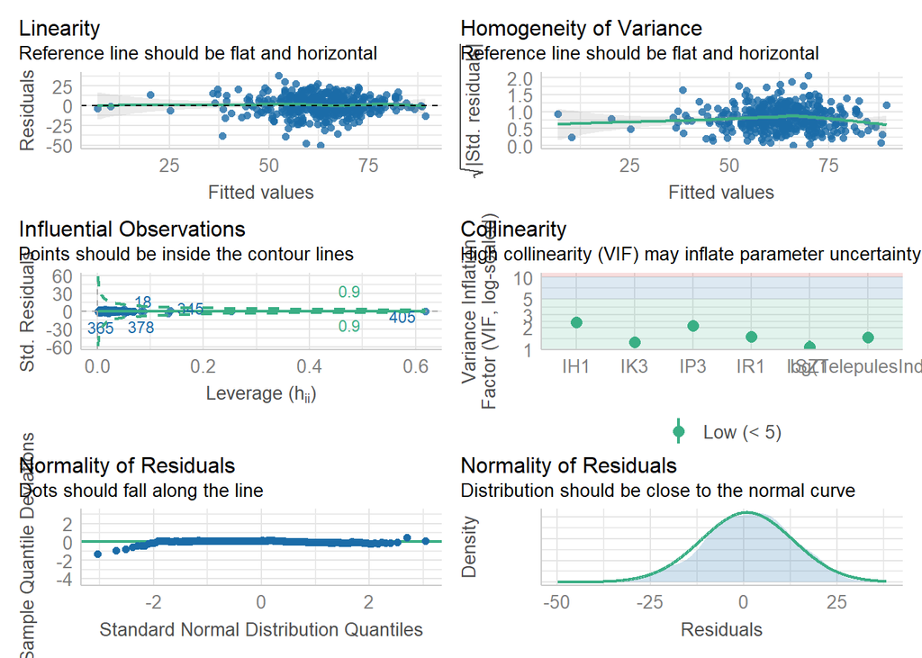

```r
#install.packages("performance")
library(performance)
check_model(KKI_reg6, check = "all")
```

```r
png("KKI_reg6_Model_diagnostics.png",
    width = 3000,
    height = 2400,
    res = 300)
check_model(KKI_reg6, check = "all")
dev.off()
```

```r
tiff("KKI_reg6_Model_diagnostics.tiff",
     width = 3000,
     height = 2400,
     res = 300,
     compression = "lzw")
check_model(KKI_reg6, check = "all")
dev.off()
```

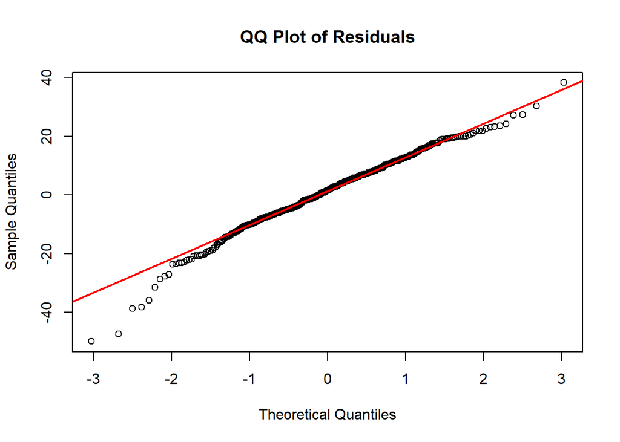

```r
residuals <- residuals(KKI_reg6)

# QQ plot for assessing the normality of the residuals
qqnorm(residuals, main = "QQ Plot of Residuals")
qqline(residuals, col = "red", lwd = 2)
```

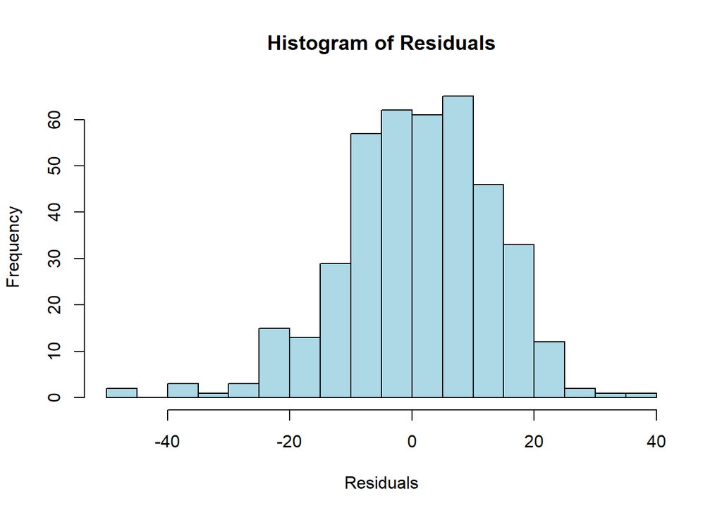

```r
# Histogram
hist(residuals, breaks = 30, main = "Histogram of Residuals", xlab = "Residuals", col = "lightblue", border = "black")
```

```r
# Shapiro–Wilk test for normality
shapiro_test <- shapiro.test(residuals)
print("Shapiro-Wilk test results:")
```

```
## [1] "Shapiro-Wilk test results:"
```

```r
print(shapiro_test)
```

```
##
##  Shapiro-Wilk normality test
##
## data:  residuals
## W = 0.9827, p-value = 8.884e-05
```

```r
# Kolmogorov–Smirnov test for normality
ks_test <- ks.test(residuals, "pnorm", mean = mean(residuals), sd = sd(residuals))
print("Kolmogorov-Smirnov test results:")
```

```
## [1] "Kolmogorov-Smirnov test results:"
```

```r
print(ks_test)
```

```
##
##  Asymptotic one-sample Kolmogorov-Smirnov test
##
## data:  residuals
## D = 0.039024, p-value = 0.5665
## alternative hypothesis: two-sided
```

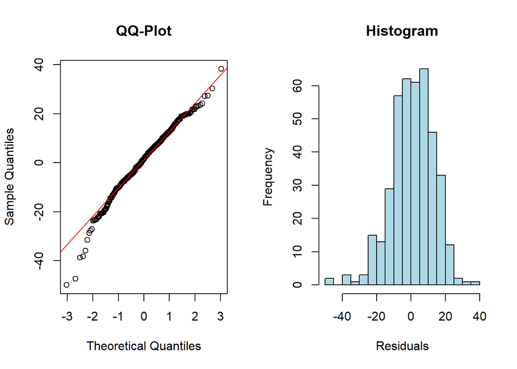

```r
# Diagnostic visualisation
par(mfrow = c(1, 2))
qqnorm(residuals, main = "QQ-Plot")
qqline(residuals, col = "red")
hist(residuals, breaks = 30, main = "Histogram", xlab = "Residuals", col = "lightblue", border = "black")
```

Export the REG6 model results to an Excel file

```r
reg6_modell_eredmenyek <- as.data.frame(summary(KKI_reg6)$coefficients)

write_xlsx(reg6_modell_eredmenyek, "reg6_modell_eredmenyek.xlsx")
```